# Modelo Predictivo Sobre el Precio del Whisky en Iowa.

En este notebook, recorreremos las fases de CRISP-DM para resolver un problema de aprendizaje supervisado de regresión utilizando árboles de decisión, Random Forest y Gradient Boosting.

El problema que vamos a resolver consiste en poder modelar el precio de los Whiskys en Iowa usado utilizando sus características.

Datos provienen de: https://catalog.data.gov/dataset/iowa-liquor-sales

# 1. Entendimiento del negocio

El sector de bebidas alcohólicas en Estados Unidos es una industria de gran relevancia económica. En 2023, este mercado generó ingresos por aproximadamente 470.696,5 millones de dólares, y se proyecta que alcance los 1.006.255,3 millones de dólares para el año 2030.

Históricamente, la producción y consumo de alcohol han estado arraigados en la cultura estadounidense desde la época colonial. Durante el siglo XVII, el ron y el whisky comenzaron a popularizarse ampliamente. Sin embargo, el sector enfrentó desafíos significativos, como la Ley Seca entre 1920 y 1933, que prohibió la producción y venta de alcohol, afectando gravemente la economía y fomentando el mercado ilegal.

Tras la anulación de la Prohibición, la industria se reestructuró y experimentó un crecimiento sostenido. En particular, el whisky estadounidense ha ganado reconocimiento internacional y ha sido un motor clave en la expansión del mercado de bebidas. La importancia económica del sector también se refleja en su contribución al empleo y a los ingresos fiscales.

#### 1.1 OBJETIVO DEL NEGOCIO

**El objetivo principal de este proyecto es predecir los precios de diferentes tipos de whisky en el estado de Iowa.** Esta predicción permite a distribuidores y comerciantes ajustar sus precios en función de variables clave, mejorando la competitividad y los márgenes de ganancia. Asimismo, facilita la identificación de patrones de consumo y tendencias en las ventas, apoyando la toma de decisiones estratégicas.

### 1.2 Preguntas del negocio

- ¿Qué variables muestran la mayor correlación con el precio del whisky?
- ¿En qué condado el modelo ofrece su mejor predicción y en cuál la más imprecisa?
- ¿Para qué número de botellas por caja (pack) el modelo alcanza su mayor precisión y para cuál su menor precisión?
- ¿Puede el modelo alcanzar un MAE inferior a un dólar?

### 1.3 Criterios de exito

Desde una perspectiva empresarial, el proyecto se considerará exitoso si cumple con los siguientes criterios:

- Determinar las variables más influyentes en la formación de precios del whisky.
- Lograr un error promedio absoluto (MAE) menor a un dólar.
- Presentar los resultados de forma clara para facilitar su interpretación.

### 1.4 Limitaciones

- El volumen del dataset original obligó a realizar un filtrado previo para facilitar el procesamiento.
- Se trabajó en equipos personales con capacidad limitada para grandes volúmenes de datos.

### 1.5 diccionario de los datos

[output not shown]

# 2. Entendimiento de datos.

##### Importaciones

```python
%pip install pandas numpy scikit-learn matplotlib datetime ipywidgets seaborn joblib
```

```
  Using cached seaborn-0.13.2-py3-none-any.whl.metadata (5.4 kB)
Using cached seaborn-0.13.2-py3-none-any.whl (294 kB)
```

```python
import pandas as pd
import sklearn
import numpy as np
import matplotlib.pylab as plt
%matplotlib inline
from matplotlib.pylab import rcParams
from datetime import datetime
import warnings
plt.rcParams.update({'font.size': 14})
warnings.filterwarnings('ignore')
```

### 2.1 Cargar correctamente la base de datos

Cargamos el dataset original de todos los tipos de licores para luego, proceder a realiar el filtrado unicamente por Whiskys

```python
data_raw=pd.read_csv("Iowa_Liquor_Sales.csv")
data_raw.shape
```

```
(31550621, 24)
```

```python
data_raw
```

|  | Invoice/Item Number | Date | Store Number | Store Name | Address | City | Zip Code | Store Location | County Number | County | ... | Item Number | Item Description | Pack | Bottle Volume (ml) | State Bottle Cost | State Bottle Retail | Bottles Sold | Sale (Dollars) | Volume Sold (Liters) | Volume Sold (Gallons) |
| --- | --- | --- | --- | --- | --- | --- | --- | --- | --- | --- | --- | --- | --- | --- | --- | --- | --- | --- | --- | --- | --- |
| 0 | S05779700049 | 05/30/2012 | 2190 | CENTRAL CITY LIQUOR, INC. | 1460 2ND AVE | DES MOINES | 50314 | POINT (-93.619787 41.60566) | 77.0 | POLK | ... | 64742 | CIROC COCONUT VODKA | 6 | 750 | 18.50 | 27.74 | 2 | 55.48 | 1.50 | 0.40 |
| 1 | S04722800004 | 03/27/2012 | 4222 | STATION MART LIQUOR AND TOBBACCO | 3594 LAFAYETTE ST | EVANSDALE | 50707 | NaN | 7.0 | BLACK HAWK | ... | 11771 | BLACK VELVET MINI | 10 | 600 | 4.96 | 7.44 | 10 | 74.40 | 6.00 | 1.59 |
| 2 | S17733800013 | 03/05/2014 | 4787 | GUPPY'S ON THE GO SWISHER | 2722 NE 120TH ST | SWISHER | 52338 | POINT (-91.664592 41.847894) | 52.0 | JOHNSON | ... | 37336 | UV VODKA | 12 | 750 | 6.50 | 9.74 | 3 | 29.22 | 2.25 | 0.59 |
| 3 | S06311400017 | 06/28/2012 | 3918 | SMOKIN' JOE'S #1 TOBACCO AND LIQUOR | 3120 ROCKINGHAM RD | DAVENPORT | 52802 | POINT (-90.621541 41.510082) | 82.0 | SCOTT | ... | 86886 | SOUTHERN COMFORT | 12 | 750 | 9.36 | 14.04 | 1 | 14.04 | 0.75 | 0.20 |
| 4 | S04410300032 | 03/06/2012 | 2591 | HY-VEE WINE AND SPIRITS / ATLANTIC | 1602 E. 7TH ST. | ATLANTIC | 50022 | POINT (-94.990031 41.403856) | 15.0 | CASS | ... | 11786 | BLACK VELVET TRAVELER | 12 | 750 | 5.23 | 7.84 | 12 | 94.08 | 9.00 | 2.38 |
| ... | ... | ... | ... | ... | ... | ... | ... | ... | ... | ... | ... | ... | ... | ... | ... | ... | ... | ... | ... | ... | ... |
| 31550616 | S17243400013 | 02/05/2014 | 4694 | RINA MART LLC / DAVENPORT | 3815, WEST KIMBERLY RD | DAVENPORT | 52806 | POINT (-90.631357 41.561712) | 82.0 | SCOTT | ... | 64727 | CIROC AMARETTO | 12 | 750 | 18.75 | 28.13 | 1 | 28.13 | 0.75 | 0.20 |
| 31550617 | S08665300032 | 10/30/2012 | 3744 | PAYLESS FOODS / DYERSVILLE | 733 16TH AVE SE | DYERSVILLE | 52040 | POINT (-91.115769 42.470204) | 31.0 | DUBUQUE | ... | 25607 | SEAGRAMS 7 CROWN BL WHISKEY | 12 | 1000 | 7.50 | 11.24 | 3 | 33.72 | 3.00 | 0.79 |
| 31550618 | S06455800018 | 07/09/2012 | 4085 | SAVE MORE FOODS / WATERLOO | 1975 FRANKLIN ST | WATERLOO | 50703 | POINT (-92.315215 42.495394) | 7.0 | BLACK HAWK | ... | 53213 | PAUL MASSON GRANDE AMBER BRANDY | 24 | 200 | 1.77 | 2.66 | 48 | 127.68 | 9.60 | 2.54 |
| 31550619 | S25449200010 | 05/04/2015 | 4819 | SUPER STOP 2 / ALTOONA | 2635 ADVENTURELAND DR | ALTOONA | 50009 | POINT (-93.494642 41.65854) | 77.0 | POLK | ... | 8825 | LAUDER'S SCOTCH TRAVELER | 12 | 750 | 5.13 | 7.70 | 12 | 92.40 | 9.00 | 2.38 |
| 31550620 | S22391900006 | 11/17/2014 | 2573 | HY-VEE FOOD STORE / MUSCATINE | 2400 2ND AVE | MUSCATINE | 52761 | POINT (-91.035138 41.451349) | 70.0 | MUSCATINE | ... | 4867 | DEWARS WHITE LABEL SCOTCH | 12 | 1000 | 16.87 | 25.31 | 4 | 101.24 | 4.00 | 1.06 |

31550621 rows × 24 columns

```python
data_raw.describe(include='all')
```

|  | Invoice/Item Number | Date | Store Number | Store Name | Address | City | Zip Code | Store Location | County Number | County | ... | Item Number | Item Description | Pack | Bottle Volume (ml) | State Bottle Cost | State Bottle Retail | Bottles Sold | Sale (Dollars) | Volume Sold (Liters) | Volume Sold (Gallons) |
| --- | --- | --- | --- | --- | --- | --- | --- | --- | --- | --- | --- | --- | --- | --- | --- | --- | --- | --- | --- | --- | --- |
| count | 31550621 | 31550621 | 3.155062e+07 | 31550621 | 31466812 | 31466813 | 31466746.0 | 29042999 | 2.413284e+07 | 31390010 | ... | 31550621.0 | 31550621 | 3.155062e+07 | 3.155062e+07 | 3.155061e+07 | 3.155061e+07 | 3.155062e+07 | 3.155061e+07 | 3.155062e+07 | 3.155062e+07 |
| unique | 31550621 | 3518 | NaN | 3427 | 3207 | 501 | 1029.0 | 11373 | NaN | 100 | ... | 16709.0 | 13607 | NaN | NaN | NaN | NaN | NaN | NaN | NaN | NaN |
| top | S22391900006 | 12/27/2022 | NaN | HY-VEE #3 / BDI / DES MOINES | 3221 SE 14TH ST | DES MOINES | 50010.0 | POINT (-93.596754 41.554101) | NaN | POLK | ... | 11788.0 | BLACK VELVET | NaN | NaN | NaN | NaN | NaN | NaN | NaN | NaN |
| freq | 1 | 18965 | NaN | 257503 | 347269 | 2680656 | 470395.0 | 189532 | NaN | 5870563 | ... | 318374.0 | 792618 | NaN | NaN | NaN | NaN | NaN | NaN | NaN | NaN |
| mean | NaN | NaN | 3.992511e+03 | NaN | NaN | NaN | NaN | NaN | 5.725913e+01 | NaN | ... | NaN | NaN | 1.210056e+01 | 8.702260e+02 | 1.093351e+01 | 1.640974e+01 | 1.092498e+01 | 1.471905e+02 | 9.136077e+00 | 2.410515e+00 |
| std | NaN | NaN | 1.428579e+03 | NaN | NaN | NaN | NaN | NaN | 2.728710e+01 | NaN | ... | NaN | NaN | 7.823935e+00 | 6.189992e+02 | 1.360883e+01 | 2.041199e+01 | 3.085598e+01 | 5.215494e+02 | 3.658921e+01 | 9.665961e+00 |
| min | NaN | NaN | 2.106000e+03 | NaN | NaN | NaN | NaN | NaN | 1.000000e+00 | NaN | ... | NaN | NaN | 1.000000e+00 | 0.000000e+00 | 0.000000e+00 | 0.000000e+00 | -7.680000e+02 | -9.720000e+03 | -1.344000e+03 | -3.550400e+02 |
| 25% | NaN | NaN | 2.624000e+03 | NaN | NaN | NaN | NaN | NaN | 3.100000e+01 | NaN | ... | NaN | NaN | 6.000000e+00 | 7.500000e+02 | 5.760000e+00 | 8.660000e+00 | 3.000000e+00 | 3.616000e+01 | 1.500000e+00 | 4.000000e-01 |
| 50% | NaN | NaN | 3.926000e+03 | NaN | NaN | NaN | NaN | NaN | 6.200000e+01 | NaN | ... | NaN | NaN | 1.200000e+01 | 7.500000e+02 | 8.620000e+00 | 1.299000e+01 | 6.000000e+00 | 7.848000e+01 | 4.800000e+00 | 1.260000e+00 |
| 75% | NaN | NaN | 4.876000e+03 | NaN | NaN | NaN | NaN | NaN | 7.700000e+01 | NaN | ... | NaN | NaN | 1.200000e+01 | 1.000000e+03 | 1.301000e+01 | 1.952000e+01 | 1.200000e+01 | 1.528800e+02 | 1.050000e+01 | 2.770000e+00 |
| max | NaN | NaN | 1.058500e+04 | NaN | NaN | NaN | NaN | NaN | 9.900000e+01 | NaN | ... | NaN | NaN | 3.360000e+02 | 3.780000e+05 | 2.498902e+04 | 3.748353e+04 | 1.500000e+04 | 2.795573e+05 | 1.500000e+04 | 3.962580e+03 |

11 rows × 24 columns

```python
data_raw.info(verbose=True, memory_usage='deep')
```

```
<class 'pandas.core.frame.DataFrame'>
RangeIndex: 31550621 entries, 0 to 31550620
Data columns (total 24 columns):
 #   Column                 Dtype
---  ------                 -----
 0   Invoice/Item Number    object
 1   Date                   object
 2   Store Number           int64
 3   Store Name             object
 4   Address                object
 5   City                   object
 6   Zip Code               object
 7   Store Location         object
 8   County Number          float64
 9   County                 object
```

[output cut: 16 more lines]

```python
data_raw["Category Name"].unique()
```

```
array(['IMPORTED VODKA - MISC', 'CANADIAN WHISKIES', 'VODKA 80 PROOF',
       'WHISKEY LIQUEUR', 'SPICED RUM', 'VODKA FLAVORED',
       'STRAIGHT BOURBON WHISKIES', 'IMPORTED SCHNAPPS',
       'AMERICAN DRY GINS', 'IMPORTED DRY GINS', 'COFFEE LIQUEURS',
       'TENNESSEE WHISKIES', 'FLAVORED RUM', 'SCOTCH WHISKIES',
       'MISC. IMPORTED CORDIALS & LIQUEURS', 'BLENDED WHISKIES',
       'TEQUILA', 'AMERICAN GRAPE BRANDIES', 'TROPICAL FRUIT SCHNAPPS',
       'IMPORTED GRAPE BRANDIES', 'AMERICAN COCKTAILS',
       'PUERTO RICO & VIRGIN ISLANDS RUM', 'STRAIGHT RYE WHISKIES',
       '100 PROOF VODKA', 'TRIPLE SEC', 'IMPORTED VODKAS',
       'CREAM LIQUEURS', 'DECANTERS & SPECIALTY PACKAGES',
       'PEPPERMINT SCHNAPPS', 'IRISH WHISKIES', 'SINGLE MALT SCOTCH',
       'BARBADOS RUM', 'PEACH SCHNAPPS', 'CINNAMON SCHNAPPS',
       'APRICOT BRANDIES', 'MISC. AMERICAN CORDIALS & LIQUEURS',
       'APPLE SCHNAPPS', 'FLAVORED GINS', 'SPEARMINT SCHNAPPS',
       'DISTILLED SPIRITS SPECIALTY', 'WHITE CREME DE CACAO',
       'AMERICAN AMARETTO', 'DARK CREME DE CACAO',
       'BUTTERSCOTCH SCHNAPPS', 'MISCELLANEOUS SCHNAPPS',
       'IMPORTED AMARETTO', 'STRAWBERRY SCHNAPPS', 'JAMAICA RUM',
       'BOTTLED IN BOND BOURBON', 'CHERRY BRANDIES',
       'BLACKBERRY BRANDIES', 'GRAPE SCHNAPPS', 'WATERMELON SCHNAPPS',
       'ROOT BEER SCHNAPPS', 'PEACH BRANDIES', 'RASPBERRY SCHNAPPS',
       'SINGLE BARREL BOURBON WHISKIES', 'GREEN CREME DE MENTHE',
       'AMERICAN ALCOHOL', 'WHITE CREME DE MENTHE', nan,
       'AMERICAN SLOE GINS', 'OTHER PROOF VODKA',
       'MISCELLANEOUS  BRANDIES', 'AMARETTO - IMPORTED', 'ANISETTE',
       'ROCK & RYE', 'CREME DE ALMOND', 'LOW PROOF VODKA',
       'CORN WHISKIES', 'HIGH PROOF BEER - AMERICAN',
       'SCHNAPPS - IMPORTED', 'TEMPORARY & SPECIALTY PACKAGES',
       'IMPORTED VODKA - CHERRY', 'JAPANESE WHISKY', 'IMPORTED BRANDIES',
       'AMERICAN VODKAS', 'IMPORTED FLAVORED VODKA',
       'AMERICAN FLAVORED VODKA', 'COCKTAILS/RTD', '100% AGAVE TEQUILA',
       'AMERICAN SCHNAPPS', 'WHITE RUM', 'MIXTO TEQUILA', 'GOLD RUM',
       'AMERICAN BRANDIES', 'SPECIAL ORDER ITEMS', 'MEZCAL',
       'IMPORTED CORDIALS & LIQUEURS', 'NEUTRAL GRAIN SPIRITS',
       'AMERICAN CORDIALS & LIQUEURS', 'AGED DARK RUM',
       'IMPORTED DISTILLED SPIRITS SPECIALTY',
       'AMERICAN DISTILLED SPIRITS SPECIALTY', 'FLAVORED GIN',
       'NEUTRAL GRAIN SPIRITS FLAVORED', 'IOWA DISTILLERY WHISKIES',
       'IOWA DISTILLERIES', 'IMPORTED GINS', 'DELISTED ITEMS',
       'DELISTED / SPECIAL ORDER ITEMS', 'IMPORTED WHISKIES',
       'AMERICAN WHISKIES', 'HOLIDAY VAP'], dtype=object)
```

Realizamos el filtrado a partir de la columna 'Category Name' para tener el conjunto de datos que vamos a usar para nuestro negocio.

```python
# Lista de categorías de whiskies o whisky
whisky_categories = ['CANADIAN WHISKIES', 'BLENDED WHISKIES', 'STRAIGHT BOURBON WHISKIES', 'IRISH WHISKIES','TENNESSEE WHISKIES', 'STRAIGHT RYE WHISKIES', 'SCOTCH WHISKIES', 'SINGLE BARREL BOURBON WHISKIES','CORN WHISKIES', 'JAPANESE WHISKY']


# Filtrar data_raw para solo tener las filas cuyo category_name está en la lista whisky_categories
filtered_data = data_raw[data_raw['Category Name'].isin(whisky_categories)]
filtered_data.reset_index(drop=True, inplace=True)

# Verificar el resultado
filtered_data
```

|  | Invoice/Item Number | Date | Store Number | Store Name | Address | City | Zip Code | Store Location | County Number | County | ... | Item Number | Item Description | Pack | Bottle Volume (ml) | State Bottle Cost | State Bottle Retail | Bottles Sold | Sale (Dollars) | Volume Sold (Liters) | Volume Sold (Gallons) |
| --- | --- | --- | --- | --- | --- | --- | --- | --- | --- | --- | --- | --- | --- | --- | --- | --- | --- | --- | --- | --- | --- |
| 0 | S04722800004 | 03/27/2012 | 4222 | STATION MART LIQUOR AND TOBBACCO | 3594 LAFAYETTE ST | EVANSDALE | 50707 | NaN | 7.0 | BLACK HAWK | ... | 11771 | BLACK VELVET MINI | 10 | 600 | 4.96 | 7.44 | 10 | 74.40 | 6.0 | 1.59 |
| 1 | S04410300032 | 03/06/2012 | 2591 | HY-VEE WINE AND SPIRITS / ATLANTIC | 1602 E. 7TH ST. | ATLANTIC | 50022 | POINT (-94.990031 41.403856) | 15.0 | CASS | ... | 11786 | BLACK VELVET TRAVELER | 12 | 750 | 5.23 | 7.84 | 12 | 94.08 | 9.0 | 2.38 |
| 2 | S24984800020 | 04/09/2015 | 2806 | OSCO #881 / CLINTON | 1307 N SECOND | CLINTON | 52732 | POINT (-90.184797 41.858932) | 23.0 | CLINTON | ... | 17958 | EVAN WILLIAMS YR STR BOURBON | 6 | 1750 | 13.71 | 21.19 | 6 | 127.14 | 10.5 | 2.77 |
| 3 | S10334900003 | 01/30/2013 | 4197 | FAREWAY STORES #014 / SERGEANT BLUFF | 700 1ST ST | SERGEANT BLUFF | 51054 | POINT (-96.353078 42.400504) | 97.0 | WOODBURY | ... | 26826 | JACK DANIELS OLD #7 BLACK LBL | 12 | 750 | 13.54 | 20.31 | 12 | 243.72 | 9.0 | 2.38 |
| 4 | S17951500022 | 03/18/2014 | 4131 | FAREWAY STORES #933 / URBANDALE | 8450 MEREDITH DR | URBANDALE | 50322 | POINT (-93.734312 41.643829) | 77.0 | POLK | ... | 5290 | J & B RARE SCOTCH | 12 | 750 | 12.25 | 18.38 | 12 | 220.56 | 9.0 | 2.38 |
| ... | ... | ... | ... | ... | ... | ... | ... | ... | ... | ... | ... | ... | ... | ... | ... | ... | ... | ... | ... | ... | ... |
| 8389601 | S07746300023 | 09/17/2012 | 2597 | HY-VEE FOOD STORE / CHEROKEE | 1300 N. SECOND | CHEROKEE | 51012 | POINT (-95.552585 42.765259) | 18.0 | CHEROKEE | ... | 11786 | BLACK VELVET TRAVELER | 12 | 750 | 4.83 | 7.44 | 12 | 89.28 | 9.0 | 2.38 |
| 8389602 | S13355500021 | 07/15/2013 | 2960 | DAHL'S / WDM | 1208 PROSPECT | WEST DES MOINES | 50265 | POINT (-93.71984 41.580977) | 77.0 | POLK | ... | 26826 | JACK DANIELS OLD #7 BLACK LBL | 12 | 750 | 14.04 | 21.05 | 12 | 252.60 | 9.0 | 2.38 |
| 8389603 | S08665300032 | 10/30/2012 | 3744 | PAYLESS FOODS / DYERSVILLE | 733 16TH AVE SE | DYERSVILLE | 52040 | POINT (-91.115769 42.470204) | 31.0 | DUBUQUE | ... | 25607 | SEAGRAMS 7 CROWN BL WHISKEY | 12 | 1000 | 7.50 | 11.24 | 3 | 33.72 | 3.0 | 0.79 |
| 8389604 | S25449200010 | 05/04/2015 | 4819 | SUPER STOP 2 / ALTOONA | 2635 ADVENTURELAND DR | ALTOONA | 50009 | POINT (-93.494642 41.65854) | 77.0 | POLK | ... | 8825 | LAUDER'S SCOTCH TRAVELER | 12 | 750 | 5.13 | 7.70 | 12 | 92.40 | 9.0 | 2.38 |
| 8389605 | S22391900006 | 11/17/2014 | 2573 | HY-VEE FOOD STORE / MUSCATINE | 2400 2ND AVE | MUSCATINE | 52761 | POINT (-91.035138 41.451349) | 70.0 | MUSCATINE | ... | 4867 | DEWARS WHITE LABEL SCOTCH | 12 | 1000 | 16.87 | 25.31 | 4 | 101.24 | 4.0 | 1.06 |

8389606 rows × 24 columns

Verificamos con unique() que se haya realizado bien el filtrado de los datos

```python
#filtered_data esta tomando los diferentes tipos de whiskies
filtered_data['Category Name'].unique()
```

```
array(['CANADIAN WHISKIES', 'STRAIGHT BOURBON WHISKIES',
       'TENNESSEE WHISKIES', 'SCOTCH WHISKIES', 'BLENDED WHISKIES',
       'STRAIGHT RYE WHISKIES', 'IRISH WHISKIES',
       'SINGLE BARREL BOURBON WHISKIES', 'CORN WHISKIES',
       'JAPANESE WHISKY'], dtype=object)
```

```python
data_elegida = filtered_data[['Date', 'Store Number', 'Zip Code', 'County Number', 'Pack', 'Bottle Volume (ml)', 'State Bottle Cost', 'Bottles Sold','Vendor Number', 'Sale (Dollars)', 'Category Name']]
data_elegida
```

|  | Date | Store Number | Zip Code | County Number | Pack | Bottle Volume (ml) | State Bottle Cost | Bottles Sold | Vendor Number | Sale (Dollars) | Category Name |
| --- | --- | --- | --- | --- | --- | --- | --- | --- | --- | --- | --- |
| 0 | 03/27/2012 | 4222 | 50707 | 7.0 | 10 | 600 | 4.96 | 10 | 115.0 | 74.40 | CANADIAN WHISKIES |
| 1 | 03/06/2012 | 2591 | 50022 | 15.0 | 12 | 750 | 5.23 | 12 | 115.0 | 94.08 | CANADIAN WHISKIES |
| 2 | 04/09/2015 | 2806 | 52732 | 23.0 | 6 | 1750 | 13.71 | 6 | 259.0 | 127.14 | STRAIGHT BOURBON WHISKIES |
| 3 | 01/30/2013 | 4197 | 51054 | 97.0 | 12 | 750 | 13.54 | 12 | 85.0 | 243.72 | TENNESSEE WHISKIES |
| 4 | 03/18/2014 | 4131 | 50322 | 77.0 | 12 | 750 | 12.25 | 12 | 260.0 | 220.56 | SCOTCH WHISKIES |
| ... | ... | ... | ... | ... | ... | ... | ... | ... | ... | ... | ... |
| 8389601 | 09/17/2012 | 2597 | 51012 | 18.0 | 12 | 750 | 4.83 | 12 | 115.0 | 89.28 | CANADIAN WHISKIES |
| 8389602 | 07/15/2013 | 2960 | 50265 | 77.0 | 12 | 750 | 14.04 | 12 | 85.0 | 252.60 | TENNESSEE WHISKIES |
| 8389603 | 10/30/2012 | 3744 | 52040 | 31.0 | 12 | 1000 | 7.50 | 3 | 260.0 | 33.72 | BLENDED WHISKIES |
| 8389604 | 05/04/2015 | 4819 | 50009 | 77.0 | 12 | 750 | 5.13 | 12 | 55.0 | 92.40 | SCOTCH WHISKIES |
| 8389605 | 11/17/2014 | 2573 | 52761 | 70.0 | 12 | 1000 | 16.87 | 4 | 35.0 | 101.24 | SCOTCH WHISKIES |

8389606 rows × 11 columns

Seleccionamos nuestras columnas de interes para el modelado de la preddicón de el precio de los Whiskys

```python
data_elegida_reset = data_elegida.reset_index(drop=True)
data_elegida_reset
```

|  | Date | Store Number | Zip Code | County Number | Pack | Bottle Volume (ml) | State Bottle Cost | Bottles Sold | Vendor Number | Sale (Dollars) | Category Name |
| --- | --- | --- | --- | --- | --- | --- | --- | --- | --- | --- | --- |
| 0 | 03/27/2012 | 4222 | 50707 | 7.0 | 10 | 600 | 4.96 | 10 | 115.0 | 74.40 | CANADIAN WHISKIES |
| 1 | 03/06/2012 | 2591 | 50022 | 15.0 | 12 | 750 | 5.23 | 12 | 115.0 | 94.08 | CANADIAN WHISKIES |
| 2 | 04/09/2015 | 2806 | 52732 | 23.0 | 6 | 1750 | 13.71 | 6 | 259.0 | 127.14 | STRAIGHT BOURBON WHISKIES |
| 3 | 01/30/2013 | 4197 | 51054 | 97.0 | 12 | 750 | 13.54 | 12 | 85.0 | 243.72 | TENNESSEE WHISKIES |
| 4 | 03/18/2014 | 4131 | 50322 | 77.0 | 12 | 750 | 12.25 | 12 | 260.0 | 220.56 | SCOTCH WHISKIES |
| ... | ... | ... | ... | ... | ... | ... | ... | ... | ... | ... | ... |
| 8389601 | 09/17/2012 | 2597 | 51012 | 18.0 | 12 | 750 | 4.83 | 12 | 115.0 | 89.28 | CANADIAN WHISKIES |
| 8389602 | 07/15/2013 | 2960 | 50265 | 77.0 | 12 | 750 | 14.04 | 12 | 85.0 | 252.60 | TENNESSEE WHISKIES |
| 8389603 | 10/30/2012 | 3744 | 52040 | 31.0 | 12 | 1000 | 7.50 | 3 | 260.0 | 33.72 | BLENDED WHISKIES |
| 8389604 | 05/04/2015 | 4819 | 50009 | 77.0 | 12 | 750 | 5.13 | 12 | 55.0 | 92.40 | SCOTCH WHISKIES |
| 8389605 | 11/17/2014 | 2573 | 52761 | 70.0 | 12 | 1000 | 16.87 | 4 | 35.0 | 101.24 | SCOTCH WHISKIES |

8389606 rows × 11 columns

### 2.2 Análisis descriptivo de los datos

```python
data_elegida_reset.head()
```

|  | Date | Store Number | Zip Code | County Number | Pack | Bottle Volume (ml) | State Bottle Cost | Bottles Sold | Vendor Number | Sale (Dollars) | Category Name |
| --- | --- | --- | --- | --- | --- | --- | --- | --- | --- | --- | --- |
| 0 | 03/27/2012 | 4222 | 50707 | 7.0 | 10 | 600 | 4.96 | 10 | 115.0 | 74.40 | CANADIAN WHISKIES |
| 1 | 03/06/2012 | 2591 | 50022 | 15.0 | 12 | 750 | 5.23 | 12 | 115.0 | 94.08 | CANADIAN WHISKIES |
| 2 | 04/09/2015 | 2806 | 52732 | 23.0 | 6 | 1750 | 13.71 | 6 | 259.0 | 127.14 | STRAIGHT BOURBON WHISKIES |
| 3 | 01/30/2013 | 4197 | 51054 | 97.0 | 12 | 750 | 13.54 | 12 | 85.0 | 243.72 | TENNESSEE WHISKIES |
| 4 | 03/18/2014 | 4131 | 50322 | 77.0 | 12 | 750 | 12.25 | 12 | 260.0 | 220.56 | SCOTCH WHISKIES |

Al observar las primeras cinco filas del dataset, se puede ver que los datos contienen información de ventas de whisky, incluyendo columnas como la fecha de la transacción, el número de tienda, código postal, número de condado, cantidad de botellas por paquete, volumen de botella en mililitros, costo estatal por botella, número de botellas vendidas, número de proveedor, el monto de venta en dólares y la categoría del whisky. Las fechas en el ejemplo varían entre los años 2012 y 2015. Las variables numéricas como *Store Number*, *Pack*, *Bottle Volume (ml)* y *Bottles Sold* aparecen en formato entero, mientras que otras variables relacionadas con costos y ventas *State Bottle Cost*, *Sale (Dollars)* están en formato decimal. Las categorías de whisky se presentan en formato texto y reflejan distintas clases, siendo una columna clave para segmentar el análisis.

```python
data_elegida_reset.describe(include="all")
```

|  | Date | Store Number | Zip Code | County Number | Pack | Bottle Volume (ml) | State Bottle Cost | Bottles Sold | Vendor Number | Sale (Dollars) | Category Name |
| --- | --- | --- | --- | --- | --- | --- | --- | --- | --- | --- | --- |
| count | 8389606 | 8.389606e+06 | 8367943.0 | 6.376930e+06 | 8.389606e+06 | 8.389606e+06 | 8.389606e+06 | 8.389606e+06 | 8.389602e+06 | 8.389606e+06 | 8389606 |
| unique | 3492 | NaN | 1019.0 | NaN | NaN | NaN | NaN | NaN | NaN | NaN | 10 |
| top | 12/27/2022 | NaN | 50010.0 | NaN | NaN | NaN | NaN | NaN | NaN | NaN | CANADIAN WHISKIES |
| freq | 5357 | NaN | 123870.0 | NaN | NaN | NaN | NaN | NaN | NaN | NaN | 3012895 |
| mean | NaN | 4.008763e+03 | NaN | 5.696741e+01 | 1.207741e+01 | 8.938504e+02 | 1.253402e+01 | 9.794379e+00 | 2.135503e+02 | 1.687672e+02 | NaN |
| std | NaN | 1.430776e+03 | NaN | 2.734576e+01 | 7.990236e+00 | 5.250608e+02 | 1.651954e+01 | 2.628807e+01 | 1.464432e+02 | 5.954848e+02 | NaN |
| min | NaN | 2.106000e+03 | NaN | 1.000000e+00 | 1.000000e+00 | 0.000000e+00 | 0.000000e+00 | -6.480000e+02 | 1.000000e+01 | -4.801680e+03 | NaN |
| 25% | NaN | 2.626000e+03 | NaN | 3.100000e+01 | 6.000000e+00 | 7.500000e+02 | 6.810000e+00 | 3.000000e+00 | 8.500000e+01 | 4.047000e+01 | NaN |
| 50% | NaN | 3.943000e+03 | NaN | 6.200000e+01 | 1.200000e+01 | 7.500000e+02 | 1.045000e+01 | 6.000000e+00 | 2.590000e+02 | 9.240000e+01 | NaN |
| 75% | NaN | 4.868000e+03 | NaN | 7.700000e+01 | 1.200000e+01 | 1.000000e+03 | 1.599000e+01 | 1.200000e+01 | 2.600000e+02 | 1.770000e+02 | NaN |
| max | NaN | 1.058500e+04 | NaN | 9.900000e+01 | 4.800000e+01 | 1.890000e+05 | 1.843600e+04 | 1.195200e+04 | 9.780000e+02 | 2.795573e+05 | NaN |

```python
data_elegida_reset.info(verbose=True)
```

```
<class 'pandas.core.frame.DataFrame'>
RangeIndex: 8389606 entries, 0 to 8389605
Data columns (total 11 columns):
 #   Column              Dtype
---  ------              -----
 0   Date                object
 1   Store Number        int64
 2   Zip Code            object
 3   County Number       float64
 4   Pack                int64
 5   Bottle Volume (ml)  int64
 6   State Bottle Cost   float64
 7   Bottles Sold        int64
 8   Vendor Number       float64
 9   Sale (Dollars)      float64
 10  Category Name       object
dtypes: float64(4), int64(4), object(3)
memory usage: 704.1+ MB
```

La estructura del dataset muestra 11 columnas con un total de 8,389,606 filas. Tres columnas están en formato objeto: la fecha *Date*, el código postal *Zip Code* y la categoría *Category Name*. Cuatro columnas están en formato entero *Store Number*, *Pack*, *Bottle Volume (ml)*, *Bottles Sold*, mientras que otras cuatro están en formato de punto flotante *County Number*, *State Bottle Cost*, *Vendor Number*, *Sale (Dollars)*.

# 3. Preparación de los datos

Al momento de preparar los datos se análizara detalladamente una por una las dimensiones de calidad de datos del dataset

```python
# Lista de columnas que quieres evaluar
columnas = [
    'Date',
    'Store Number',
    'Zip Code',
    'County Number',
    'Pack',
    'Bottle Volume (ml)',
    'State Bottle Cost',
    'Vendor Number',
    'Bottles Sold',
    'Sale (Dollars)'
]

# Calcular el tamaño en MB de cada columna
tamanos_bytes = data_elegida_reset[columnas].memory_usage(deep=True)
tamanos_mb = (tamanos_bytes / (1024 ** 2)).round(2)

# Mostrar los resultados como tabla
df_tamanos = tamanos_mb.reset_index()
df_tamanos.columns = ['Campo', 'Tamaño (MB)']

df_tamanos
```

|  | Campo | Tamaño (MB) |
| --- | --- | --- |
| 0 | Index | 0.00 |
| 1 | Date | 472.06 |
| 2 | Store Number | 64.01 |
| 3 | Zip Code | 321.33 |
| 4 | County Number | 64.01 |
| 5 | Pack | 64.01 |
| 6 | Bottle Volume (ml) | 64.01 |
| 7 | State Bottle Cost | 64.01 |
| 8 | Vendor Number | 64.01 |
| 9 | Bottles Sold | 64.01 |
| 10 | Sale (Dollars) | 64.01 |

### 3.1 **Completitud**

```python
data_elegida_reset.isnull().sum()
```

```
Date                        0
Store Number                0
Zip Code                21663
County Number         2012676
Pack                        0
Bottle Volume (ml)          0
State Bottle Cost           0
Bottles Sold                0
Vendor Number               4
Sale (Dollars)              0
Category Name               0
dtype: int64
```

```python
# Paso 1: calcular el número de nulos por columna
nulos_por_columna = data_elegida_reset.isnull().sum()

# Paso 2: seleccionar solo las columnas que tienen valores nulos
columnas_con_un_nulo = nulos_por_columna.index

# Paso 3: eliminar las filas que tengan nulos en esas columnas
data_filtrada = data_elegida_reset.dropna(subset=columnas_con_un_nulo)
```

```python
data_filtrada.isnull().sum()
```

```
Date                  0
Store Number          0
Zip Code              0
County Number         0
Pack                  0
Bottle Volume (ml)    0
State Bottle Cost     0
Bottles Sold          0
Vendor Number         0
Sale (Dollars)        0
Category Name         0
dtype: int64
```

```python
data_filtrada_reset = data_filtrada.reset_index(drop=True)
data_filtrada_reset
```

|  | Date | Store Number | Zip Code | County Number | Pack | Bottle Volume (ml) | State Bottle Cost | Bottles Sold | Vendor Number | Sale (Dollars) | Category Name |
| --- | --- | --- | --- | --- | --- | --- | --- | --- | --- | --- | --- |
| 0 | 03/27/2012 | 4222 | 50707 | 7.0 | 10 | 600 | 4.96 | 10 | 115.0 | 74.40 | CANADIAN WHISKIES |
| 1 | 03/06/2012 | 2591 | 50022 | 15.0 | 12 | 750 | 5.23 | 12 | 115.0 | 94.08 | CANADIAN WHISKIES |
| 2 | 04/09/2015 | 2806 | 52732 | 23.0 | 6 | 1750 | 13.71 | 6 | 259.0 | 127.14 | STRAIGHT BOURBON WHISKIES |
| 3 | 01/30/2013 | 4197 | 51054 | 97.0 | 12 | 750 | 13.54 | 12 | 85.0 | 243.72 | TENNESSEE WHISKIES |
| 4 | 03/18/2014 | 4131 | 50322 | 77.0 | 12 | 750 | 12.25 | 12 | 260.0 | 220.56 | SCOTCH WHISKIES |
| ... | ... | ... | ... | ... | ... | ... | ... | ... | ... | ... | ... |
| 6376921 | 09/17/2012 | 2597 | 51012 | 18.0 | 12 | 750 | 4.83 | 12 | 115.0 | 89.28 | CANADIAN WHISKIES |
| 6376922 | 07/15/2013 | 2960 | 50265 | 77.0 | 12 | 750 | 14.04 | 12 | 85.0 | 252.60 | TENNESSEE WHISKIES |
| 6376923 | 10/30/2012 | 3744 | 52040 | 31.0 | 12 | 1000 | 7.50 | 3 | 260.0 | 33.72 | BLENDED WHISKIES |
| 6376924 | 05/04/2015 | 4819 | 50009 | 77.0 | 12 | 750 | 5.13 | 12 | 55.0 | 92.40 | SCOTCH WHISKIES |
| 6376925 | 11/17/2014 | 2573 | 52761 | 70.0 | 12 | 1000 | 16.87 | 4 | 35.0 | 101.24 | SCOTCH WHISKIES |

6376926 rows × 11 columns

### **3.2 Consistencia**

```python
#Verificar que las variables numéricas sean positivas
columnas_positivas = ['Store Number', 'County Number', 'Pack', 'Bottle Volume (ml)', 'State Bottle Cost', 'Bottles Sold','Vendor Number', 'Sale (Dollars)']

for col in columnas_positivas:
    negativos = data_filtrada_reset[data_filtrada_reset[col] < 0]
    if not negativos.empty:
        print(f"⚠️ Hay valores negativos en '{col}': {len(negativos)} filas")
    else:
        print(f" '{col}' no tiene valores negativos")
```

```
 'Store Number' no tiene valores negativos
 'County Number' no tiene valores negativos
 'Pack' no tiene valores negativos
 'Bottle Volume (ml)' no tiene valores negativos
 'State Bottle Cost' no tiene valores negativos
 'Bottles Sold' no tiene valores negativos
 'Vendor Number' no tiene valores negativos
 'Sale (Dollars)' no tiene valores negativos
```

```python
# Columnas a verificar
columnas_objetivo = ['Bottle Volume (ml)', 'State Bottle Cost', 'Bottles Sold', 'Sale (Dollars)']

# Asegurarse de que las columnas son numéricas (si no lo son, convertirlas)
for col in columnas_objetivo:
    data_filtrada_reset[col] = pd.to_numeric(data_filtrada_reset[col], errors='coerce')

# Filtrar filas con valor 0 en cualquiera de las columnas
filas_con_ceros = data_filtrada_reset[
    (data_filtrada_reset['Bottle Volume (ml)'] == 0) |
    (data_filtrada_reset['State Bottle Cost'] == 0) |
    (data_filtrada_reset['Bottles Sold'] == 0) |
    (data_filtrada_reset['Sale (Dollars)'] == 0)
]

# Mostrar cuántas filas tienen valores 0
print(f"Filas con 0 en columnas clave: {filas_con_ceros.shape[0]}")
display(filas_con_ceros[columnas_objetivo])

# Eliminar esas filas del DataFrame original
data_filtrada_reset = data_filtrada_reset.drop(filas_con_ceros.index).reset_index(drop=True)

print(f"\nFilas después de eliminar: {data_filtrada_reset.shape[0]}")
```

```
Filas con 0 en columnas clave: 491
```

|  | Bottle Volume (ml) | State Bottle Cost | Bottles Sold | Sale (Dollars) |
| --- | --- | --- | --- | --- |
| 242986 | 0 | 4.80 | 12 | 86.4 |
| 546632 | 1750 | 20.99 | 1 | 0.0 |
| 1076376 | 750 | 23.49 | 4 | 0.0 |
| 1163937 | 375 | 8.00 | 1 | 0.0 |
| 1166026 | 1750 | 10.45 | 1 | 0.0 |
| ... | ... | ... | ... | ... |
| 3466402 | 375 | 8.00 | 1 | 0.0 |
| 3466471 | 750 | 5.13 | 1 | 0.0 |
| 3466763 | 375 | 7.50 | 1 | 0.0 |
| 5448092 | 375 | 0.00 | 6 | 0.0 |
| 5518066 | 1750 | 0.00 | 6 | 0.0 |

491 rows × 4 columns

```
Filas después de eliminar: 6376435
```

```python
data_filtrada_reset1 = data_filtrada_reset.reset_index(drop=True)
data_filtrada_reset1
```

|  | Date | Store Number | Zip Code | County Number | Pack | Bottle Volume (ml) | State Bottle Cost | Bottles Sold | Vendor Number | Sale (Dollars) | Category Name |
| --- | --- | --- | --- | --- | --- | --- | --- | --- | --- | --- | --- |
| 0 | 03/27/2012 | 4222 | 50707 | 7.0 | 10 | 600 | 4.96 | 10 | 115.0 | 74.40 | CANADIAN WHISKIES |
| 1 | 03/06/2012 | 2591 | 50022 | 15.0 | 12 | 750 | 5.23 | 12 | 115.0 | 94.08 | CANADIAN WHISKIES |
| 2 | 04/09/2015 | 2806 | 52732 | 23.0 | 6 | 1750 | 13.71 | 6 | 259.0 | 127.14 | STRAIGHT BOURBON WHISKIES |
| 3 | 01/30/2013 | 4197 | 51054 | 97.0 | 12 | 750 | 13.54 | 12 | 85.0 | 243.72 | TENNESSEE WHISKIES |
| 4 | 03/18/2014 | 4131 | 50322 | 77.0 | 12 | 750 | 12.25 | 12 | 260.0 | 220.56 | SCOTCH WHISKIES |
| ... | ... | ... | ... | ... | ... | ... | ... | ... | ... | ... | ... |
| 6376430 | 09/17/2012 | 2597 | 51012 | 18.0 | 12 | 750 | 4.83 | 12 | 115.0 | 89.28 | CANADIAN WHISKIES |
| 6376431 | 07/15/2013 | 2960 | 50265 | 77.0 | 12 | 750 | 14.04 | 12 | 85.0 | 252.60 | TENNESSEE WHISKIES |
| 6376432 | 10/30/2012 | 3744 | 52040 | 31.0 | 12 | 1000 | 7.50 | 3 | 260.0 | 33.72 | BLENDED WHISKIES |
| 6376433 | 05/04/2015 | 4819 | 50009 | 77.0 | 12 | 750 | 5.13 | 12 | 55.0 | 92.40 | SCOTCH WHISKIES |
| 6376434 | 11/17/2014 | 2573 | 52761 | 70.0 | 12 | 1000 | 16.87 | 4 | 35.0 | 101.24 | SCOTCH WHISKIES |

6376435 rows × 11 columns

### **3.3 Conformidad/Validez**

```python
# Convertir 'Date' a datetime (formato mm/dd/yyyy), marcando errores como NaT
data_filtrada_reset1['Date'] = pd.to_datetime(data_filtrada_reset1['Date'], format='%m/%d/%Y', errors='coerce')

# Identificar y mostrar cuántas fechas son inválidas
fechas_malas = data_filtrada_reset1['Date'].isna()
print(f"Cantidad de fechas mal formateadas: {fechas_malas.sum()}")

# Mostrar las fechas mal formateadas (opcional)
print("Fechas mal formateadas:")
print(data_filtrada_reset1.loc[fechas_malas, 'Date'])

# Eliminar las filas con fechas inválidas
data_filtrada_reset1 = data_filtrada_reset1.dropna(subset=['Date']).reset_index(drop=True)

# Convertir la columna 'Date' a entero con formato YYYYMMDD
data_filtrada_reset1['Date'] = data_filtrada_reset1['Date'].dt.strftime('%Y%m%d').astype(int)

# Verificamos
print("\nTipo final de 'Date':", data_filtrada_reset1['Date'].dtype)
print(data_filtrada_reset1[['Date']].head())
```

```
Cantidad de fechas mal formateadas: 0
Fechas mal formateadas:
Series([], Name: Date, dtype: datetime64[ns])

Tipo final de 'Date': int64
       Date
0  20120327
1  20120306
2  20150409
3  20130130
4  20140318
```

```python
data_filtrada_reset1[data_filtrada_reset1['Date'] == 'NaN']
```

|  | Date | Store Number | Zip Code | County Number | Pack | Bottle Volume (ml) | State Bottle Cost | Bottles Sold | Vendor Number | Sale (Dollars) | Category Name |
| --- | --- | --- | --- | --- | --- | --- | --- | --- | --- | --- | --- |

```python
#Si se volvio int Date
#data_filtrada_reset1.info()
```

```python
# ZIP code en USA tiene 5 dígitos
# En Iowa empieza con 50 o 52
# El rango completo en Iowa va de 50001 a 52809.

# Aseguramos que 'Zip Code' esté en formato string para validación
data_filtrada_reset1['Zip Code'] = data_filtrada_reset1['Zip Code'].astype(str)

# Identificamos los ZIP mal formateados (no tienen exactamente 5 dígitos numéricos)
zip_mal_formato = ~data_filtrada_reset1['Zip Code'].str.match(r'^\d{5}$')

# Convertimos a número para poder verificar el rango válido de Iowa
data_filtrada_reset1['Zip Code Num'] = pd.to_numeric(data_filtrada_reset1['Zip Code'], errors='coerce')

# ZIP fuera del rango válido para Iowa (50001 a 52809)
zip_fuera_rango = (data_filtrada_reset1['Zip Code Num'] < 50001) | (data_filtrada_reset1['Zip Code Num'] > 52809)

# Combinamos los casos inválidos
zip_invalidos = zip_mal_formato | zip_fuera_rango

# Mostramos información de los ZIP inválidos
print(f"Cantidad de ZIP Codes inválidos: {zip_invalidos.sum()}")
print("Ejemplos de ZIP Codes inválidos:")
print(data_filtrada_reset1.loc[zip_invalidos, 'Zip Code'].unique())

# Creamos el nuevo DataFrame sin ZIP inválidos
data_filtrada2 = data_filtrada_reset1[~zip_invalidos].copy()

# Reemplazamos 'Zip Code' por su versión numérica como int
data_filtrada2['Zip Code'] = data_filtrada2['Zip Code Num'].astype(int)

# Eliminamos columna auxiliar
data_filtrada2 = data_filtrada2.drop(columns=['Zip Code Num']).reset_index(drop=True)

# Mostramos resultado final
print(f"\nNuevo tamaño del DataFrame sin ZIP Codes inválidos: {data_filtrada2.shape}")
print(f"Tipo de dato final de 'Zip Code': {data_filtrada2['Zip Code'].dtype}")
```

[output not shown]

[output cut: 22 more lines]

```
 '50150.0' '52146.0' '50261.0' '50071.0' '52767.0' '52218.0' '50160.0'
 '52202.0' '50257.0' '52337.0' '52339.0' '52223.0' '51338.0' '52554.0'
 '50606.0' '50046.0' '50846.0' '52004.0' '52306.0' '52625.0' '50590.0'
 '50005.0' '51003.0' '50650.0' '50540.0' '52228.0' '52037.0' '57222'
 '52773.0' '57222.0' '50558.0' '52755.0' '52216.0' '52036.0' '50162.0'
 '52235.0' '52638.0' '50471.0' '52553.0' '50864.0' '51638.0' '50655.0'
 '50268.0' '52561.0' '52766.0' '51024.0' '52640.0' '50008.0' '52155.0'
 '51458.0' '52305.0' '52161.0' '50598.0' '52035.0' '50157.0' '52056.0'
 '51234.0' '52362.0' '51570.0' '50106.0' '51039.0' '51652.0' '52320.0'
 '50166.0' '52069.0' '52631.0' '52533.0' '50174.0' '52249.0' '50575.0'
 '50336.0' '52570.0' '52649.0' '52620.0' '52624.0' '52535.0' '52201.0'
 '50044.0' '51061.0' '50603.0']

Nuevo tamaño del DataFrame sin ZIP Codes inválidos: (3478376, 11)
Tipo de dato final de 'Zip Code': int64
```

```python
data_filtrada2 = data_filtrada2.reset_index(drop=True)
data_filtrada2
```

|  | Date | Store Number | Zip Code | County Number | Pack | Bottle Volume (ml) | State Bottle Cost | Bottles Sold | Vendor Number | Sale (Dollars) | Category Name |
| --- | --- | --- | --- | --- | --- | --- | --- | --- | --- | --- | --- |
| 0 | 20120327 | 4222 | 50707 | 7.0 | 10 | 600 | 4.96 | 10 | 115.0 | 74.40 | CANADIAN WHISKIES |
| 1 | 20120306 | 2591 | 50022 | 15.0 | 12 | 750 | 5.23 | 12 | 115.0 | 94.08 | CANADIAN WHISKIES |
| 2 | 20150409 | 2806 | 52732 | 23.0 | 6 | 1750 | 13.71 | 6 | 259.0 | 127.14 | STRAIGHT BOURBON WHISKIES |
| 3 | 20130130 | 4197 | 51054 | 97.0 | 12 | 750 | 13.54 | 12 | 85.0 | 243.72 | TENNESSEE WHISKIES |
| 4 | 20140318 | 4131 | 50322 | 77.0 | 12 | 750 | 12.25 | 12 | 260.0 | 220.56 | SCOTCH WHISKIES |
| ... | ... | ... | ... | ... | ... | ... | ... | ... | ... | ... | ... |
| 3478371 | 20120917 | 2597 | 51012 | 18.0 | 12 | 750 | 4.83 | 12 | 115.0 | 89.28 | CANADIAN WHISKIES |
| 3478372 | 20130715 | 2960 | 50265 | 77.0 | 12 | 750 | 14.04 | 12 | 85.0 | 252.60 | TENNESSEE WHISKIES |
| 3478373 | 20121030 | 3744 | 52040 | 31.0 | 12 | 1000 | 7.50 | 3 | 260.0 | 33.72 | BLENDED WHISKIES |
| 3478374 | 20150504 | 4819 | 50009 | 77.0 | 12 | 750 | 5.13 | 12 | 55.0 | 92.40 | SCOTCH WHISKIES |
| 3478375 | 20141117 | 2573 | 52761 | 70.0 | 12 | 1000 | 16.87 | 4 | 35.0 | 101.24 | SCOTCH WHISKIES |

3478376 rows × 11 columns

```python
data_filtrada2.info()
```

```
<class 'pandas.core.frame.DataFrame'>
RangeIndex: 3478376 entries, 0 to 3478375
Data columns (total 11 columns):
 #   Column              Dtype
---  ------              -----
 0   Date                int64
 1   Store Number        int64
 2   Zip Code            int64
 3   County Number       float64
 4   Pack                int64
 5   Bottle Volume (ml)  int64
 6   State Bottle Cost   float64
 7   Bottles Sold        int64
 8   Vendor Number       float64
 9   Sale (Dollars)      float64
 10  Category Name       object
dtypes: float64(4), int64(6), object(1)
memory usage: 291.9+ MB
```

```python
# Ver cuántos County Number son inválidos (nulos o fuera del rango 1-99)
invalid_county = data_filtrada2[
    (data_filtrada2['County Number'].isnull()) |
    (~data_filtrada2['County Number'].astype(int).between(1, 99))
]

print(f"Cantidad de registros con 'County Number' inválido: {invalid_county.shape[0]}")
```

```
Cantidad de registros con 'County Number' inválido: 0
```

### **3.4 Duplicidad**

```python
# Ver cuántas filas duplicadas hay (completamente idénticas)
duplicadas = data_filtrada2.duplicated()
print(f"Filas duplicadas exactamente: {duplicadas.sum()}")

# Eliminar duplicados exactos
data_filtrada2 = data_filtrada2.drop_duplicates().reset_index(drop=True)

print(f"Nuevo tamaño del DataFrame sin duplicados: {data_filtrada2.shape}")
```

```
Filas duplicadas exactamente: 66740
Nuevo tamaño del DataFrame sin duplicados: (3411636, 11)
```

```python
data_filtrada2 = data_filtrada2.reset_index(drop=True)
data_filtrada2
```

|  | Date | Store Number | Zip Code | County Number | Pack | Bottle Volume (ml) | State Bottle Cost | Bottles Sold | Vendor Number | Sale (Dollars) | Category Name |
| --- | --- | --- | --- | --- | --- | --- | --- | --- | --- | --- | --- |
| 0 | 20120327 | 4222 | 50707 | 7.0 | 10 | 600 | 4.96 | 10 | 115.0 | 74.40 | CANADIAN WHISKIES |
| 1 | 20120306 | 2591 | 50022 | 15.0 | 12 | 750 | 5.23 | 12 | 115.0 | 94.08 | CANADIAN WHISKIES |
| 2 | 20150409 | 2806 | 52732 | 23.0 | 6 | 1750 | 13.71 | 6 | 259.0 | 127.14 | STRAIGHT BOURBON WHISKIES |
| 3 | 20130130 | 4197 | 51054 | 97.0 | 12 | 750 | 13.54 | 12 | 85.0 | 243.72 | TENNESSEE WHISKIES |
| 4 | 20140318 | 4131 | 50322 | 77.0 | 12 | 750 | 12.25 | 12 | 260.0 | 220.56 | SCOTCH WHISKIES |
| ... | ... | ... | ... | ... | ... | ... | ... | ... | ... | ... | ... |
| 3411631 | 20120917 | 2597 | 51012 | 18.0 | 12 | 750 | 4.83 | 12 | 115.0 | 89.28 | CANADIAN WHISKIES |
| 3411632 | 20130715 | 2960 | 50265 | 77.0 | 12 | 750 | 14.04 | 12 | 85.0 | 252.60 | TENNESSEE WHISKIES |
| 3411633 | 20121030 | 3744 | 52040 | 31.0 | 12 | 1000 | 7.50 | 3 | 260.0 | 33.72 | BLENDED WHISKIES |
| 3411634 | 20150504 | 4819 | 50009 | 77.0 | 12 | 750 | 5.13 | 12 | 55.0 | 92.40 | SCOTCH WHISKIES |
| 3411635 | 20141117 | 2573 | 52761 | 70.0 | 12 | 1000 | 16.87 | 4 | 35.0 | 101.24 | SCOTCH WHISKIES |

3411636 rows × 11 columns

```python
#Z score
from scipy.stats import zscore
import numpy as np

# Columnas numéricas relevantes
columnas_zscore = [
    'Store Number', 'County Number', 'Pack', 'Bottle Volume (ml)', 'State Bottle Cost', 'Bottles Sold','Vendor Number', 'Sale (Dollars)'
]

# Cálculo del Z-score
z_scores = np.abs(zscore(data_filtrada2[columnas_zscore]))

# Identificación de filas con al menos un valor atípico
outlier_rows = (z_scores > 3).any(axis=1)

print(f"Filas con al menos un outlier: {outlier_rows.sum()} de {len(data_filtrada2)}")
```

```
Filas con al menos un outlier: 177708 de 3411636
```

```python
# Eliminamos las filas con outliers y sobrescribimos la variable original
data_filtrada2 = data_filtrada2.drop(data_filtrada2[outlier_rows].index).reset_index(drop=True)

print(f"Nuevo tamaño del DataFrame sin outliers: {data_filtrada2.shape}")
```

```
Nuevo tamaño del DataFrame sin outliers: (3233928, 11)
```

```python
data_filtrada2 = data_filtrada2.reset_index(drop=True)
data_filtrada2
```

|  | Date | Store Number | Zip Code | County Number | Pack | Bottle Volume (ml) | State Bottle Cost | Bottles Sold | Vendor Number | Sale (Dollars) | Category Name |
| --- | --- | --- | --- | --- | --- | --- | --- | --- | --- | --- | --- |
| 0 | 20120327 | 4222 | 50707 | 7.0 | 10 | 600 | 4.96 | 10 | 115.0 | 74.40 | CANADIAN WHISKIES |
| 1 | 20120306 | 2591 | 50022 | 15.0 | 12 | 750 | 5.23 | 12 | 115.0 | 94.08 | CANADIAN WHISKIES |
| 2 | 20150409 | 2806 | 52732 | 23.0 | 6 | 1750 | 13.71 | 6 | 259.0 | 127.14 | STRAIGHT BOURBON WHISKIES |
| 3 | 20130130 | 4197 | 51054 | 97.0 | 12 | 750 | 13.54 | 12 | 85.0 | 243.72 | TENNESSEE WHISKIES |
| 4 | 20140318 | 4131 | 50322 | 77.0 | 12 | 750 | 12.25 | 12 | 260.0 | 220.56 | SCOTCH WHISKIES |
| ... | ... | ... | ... | ... | ... | ... | ... | ... | ... | ... | ... |
| 3233923 | 20120917 | 2597 | 51012 | 18.0 | 12 | 750 | 4.83 | 12 | 115.0 | 89.28 | CANADIAN WHISKIES |
| 3233924 | 20130715 | 2960 | 50265 | 77.0 | 12 | 750 | 14.04 | 12 | 85.0 | 252.60 | TENNESSEE WHISKIES |
| 3233925 | 20121030 | 3744 | 52040 | 31.0 | 12 | 1000 | 7.50 | 3 | 260.0 | 33.72 | BLENDED WHISKIES |
| 3233926 | 20150504 | 4819 | 50009 | 77.0 | 12 | 750 | 5.13 | 12 | 55.0 | 92.40 | SCOTCH WHISKIES |
| 3233927 | 20141117 | 2573 | 52761 | 70.0 | 12 | 1000 | 16.87 | 4 | 35.0 | 101.24 | SCOTCH WHISKIES |

3233928 rows × 11 columns

#### **3.4.1 One hot encoding**

```python
# Verificar valores únicos
print(data_filtrada2["Category Name"].unique())

# Verificar valores nulos
print(data_filtrada2["Category Name"].isnull().sum())
```

```
['CANADIAN WHISKIES' 'STRAIGHT BOURBON WHISKIES' 'TENNESSEE WHISKIES'
 'SCOTCH WHISKIES' 'BLENDED WHISKIES' 'STRAIGHT RYE WHISKIES'
 'IRISH WHISKIES' 'SINGLE BARREL BOURBON WHISKIES' 'CORN WHISKIES'
 'JAPANESE WHISKY']
0
```

```python
# Aplicar One-Hot Encoding con un prefijo
onehot_encoded = pd.get_dummies(data_filtrada2["Category Name"], prefix="Category")

# Ver las primeras filas del resultado
onehot_encoded
```

|  | Category_BLENDED WHISKIES | Category_CANADIAN WHISKIES | Category_CORN WHISKIES | Category_IRISH WHISKIES | Category_JAPANESE WHISKY | Category_SCOTCH WHISKIES | Category_SINGLE BARREL BOURBON WHISKIES | Category_STRAIGHT BOURBON WHISKIES | Category_STRAIGHT RYE WHISKIES | Category_TENNESSEE WHISKIES |
| --- | --- | --- | --- | --- | --- | --- | --- | --- | --- | --- |
| 0 | False | True | False | False | False | False | False | False | False | False |
| 1 | False | True | False | False | False | False | False | False | False | False |
| 2 | False | False | False | False | False | False | False | True | False | False |
| 3 | False | False | False | False | False | False | False | False | False | True |
| 4 | False | False | False | False | False | True | False | False | False | False |
| ... | ... | ... | ... | ... | ... | ... | ... | ... | ... | ... |
| 3233923 | False | True | False | False | False | False | False | False | False | False |
| 3233924 | False | False | False | False | False | False | False | False | False | True |
| 3233925 | True | False | False | False | False | False | False | False | False | False |
| 3233926 | False | False | False | False | False | True | False | False | False | False |
| 3233927 | False | False | False | False | False | True | False | False | False | False |

3233928 rows × 10 columns

```python
# Eliminar la columna original
data_filtrada2 = data_filtrada2.drop("Category Name", axis=1)

# Unir las columnas codificadas
data_filtrada2 = pd.concat([data_filtrada2, onehot_encoded], axis=1)
```

```python
data_modificada = data_filtrada2.reset_index(drop=True)
data_modificada
```

|  | Date | Store Number | Zip Code | County Number | Pack | Bottle Volume (ml) | State Bottle Cost | Bottles Sold | Vendor Number | Sale (Dollars) | Category_BLENDED WHISKIES | Category_CANADIAN WHISKIES | Category_CORN WHISKIES | Category_IRISH WHISKIES | Category_JAPANESE WHISKY | Category_SCOTCH WHISKIES | Category_SINGLE BARREL BOURBON WHISKIES | Category_STRAIGHT BOURBON WHISKIES | Category_STRAIGHT RYE WHISKIES | Category_TENNESSEE WHISKIES |
| --- | --- | --- | --- | --- | --- | --- | --- | --- | --- | --- | --- | --- | --- | --- | --- | --- | --- | --- | --- | --- |
| 0 | 20120327 | 4222 | 50707 | 7.0 | 10 | 600 | 4.96 | 10 | 115.0 | 74.40 | False | True | False | False | False | False | False | False | False | False |
| 1 | 20120306 | 2591 | 50022 | 15.0 | 12 | 750 | 5.23 | 12 | 115.0 | 94.08 | False | True | False | False | False | False | False | False | False | False |
| 2 | 20150409 | 2806 | 52732 | 23.0 | 6 | 1750 | 13.71 | 6 | 259.0 | 127.14 | False | False | False | False | False | False | False | True | False | False |
| 3 | 20130130 | 4197 | 51054 | 97.0 | 12 | 750 | 13.54 | 12 | 85.0 | 243.72 | False | False | False | False | False | False | False | False | False | True |
| 4 | 20140318 | 4131 | 50322 | 77.0 | 12 | 750 | 12.25 | 12 | 260.0 | 220.56 | False | False | False | False | False | True | False | False | False | False |
| ... | ... | ... | ... | ... | ... | ... | ... | ... | ... | ... | ... | ... | ... | ... | ... | ... | ... | ... | ... | ... |
| 3233923 | 20120917 | 2597 | 51012 | 18.0 | 12 | 750 | 4.83 | 12 | 115.0 | 89.28 | False | True | False | False | False | False | False | False | False | False |
| 3233924 | 20130715 | 2960 | 50265 | 77.0 | 12 | 750 | 14.04 | 12 | 85.0 | 252.60 | False | False | False | False | False | False | False | False | False | True |
| 3233925 | 20121030 | 3744 | 52040 | 31.0 | 12 | 1000 | 7.50 | 3 | 260.0 | 33.72 | True | False | False | False | False | False | False | False | False | False |
| 3233926 | 20150504 | 4819 | 50009 | 77.0 | 12 | 750 | 5.13 | 12 | 55.0 | 92.40 | False | False | False | False | False | True | False | False | False | False |
| 3233927 | 20141117 | 2573 | 52761 | 70.0 | 12 | 1000 | 16.87 | 4 | 35.0 | 101.24 | False | False | False | False | False | True | False | False | False | False |

3233928 rows × 20 columns

```python
data_modificada.info()
```

```
<class 'pandas.core.frame.DataFrame'>
RangeIndex: 3233928 entries, 0 to 3233927
Data columns (total 20 columns):
 #   Column                                   Dtype
---  ------                                   -----
 0   Date                                     int64
 1   Store Number                             int64
 2   Zip Code                                 int64
 3   County Number                            float64
 4   Pack                                     int64
 5   Bottle Volume (ml)                       int64
 6   State Bottle Cost                        float64
 7   Bottles Sold                             int64
 8   Vendor Number                            float64
 9   Sale (Dollars)                           float64
 10  Category_BLENDED WHISKIES                bool
 11  Category_CANADIAN WHISKIES               bool
 12  Category_CORN WHISKIES                   bool
 13  Category_IRISH WHISKIES                  bool
 14  Category_JAPANESE WHISKY                 bool
 15  Category_SCOTCH WHISKIES                 bool
 16  Category_SINGLE BARREL BOURBON WHISKIES  bool
 17  Category_STRAIGHT BOURBON WHISKIES       bool
 18  Category_STRAIGHT RYE WHISKIES           bool
 19  Category_TENNESSEE WHISKIES              bool
dtypes: bool(10), float64(4), int64(6)
memory usage: 277.6 MB
```

### **3.5 Distancia Mahalanobis**

```
Cantidad de outliers detectados (Mahalanobis): 174656 registros
```

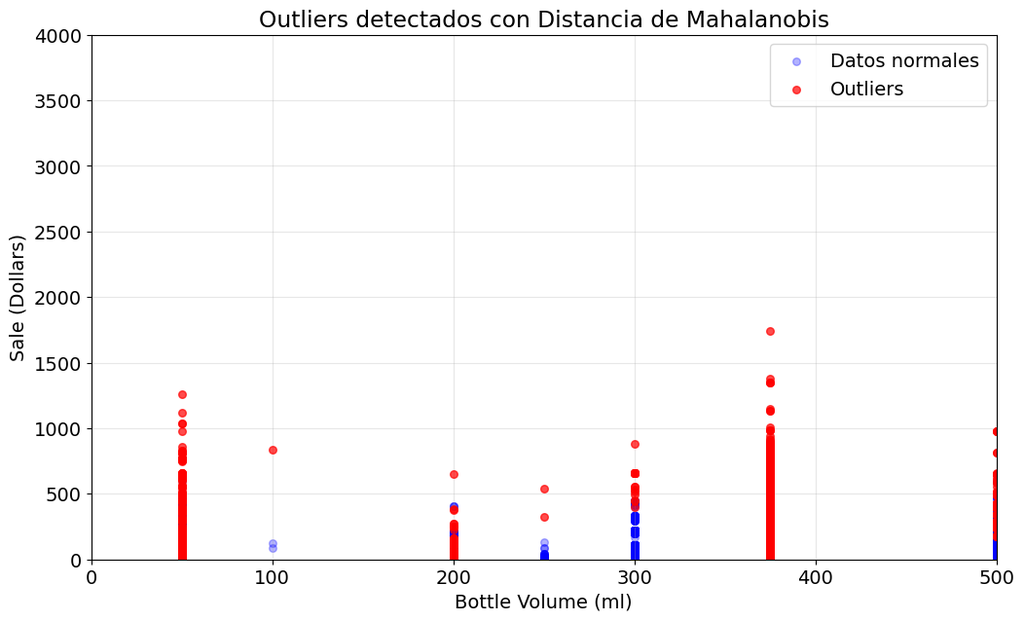

```python
import numpy as np
import pandas as pd
import matplotlib.pyplot as plt
from scipy.stats import chi2
from scipy.spatial.distance import mahalanobis
from sklearn.preprocessing import StandardScaler

# Función para detectar outliers usando la distancia de Mahalanobis
def detectar_outliers_mahalanobis_completo(data_modificada):
    # Variables seleccionadas
    columnas = columnas = [
    'Date',
    'Store Number',
    'Zip Code',
    'County Number',
    'Pack',
    'Bottle Volume (ml)',
    'State Bottle Cost',
    'Bottles Sold',
    'Vendor Number',
    'Sale (Dollars)',
    'Category_BLENDED WHISKIES',
    'Category_CANADIAN WHISKIES',
    'Category_CORN WHISKIES',
    'Category_IRISH WHISKIES',
    'Category_JAPANESE WHISKY',
    'Category_SCOTCH WHISKIES',
    'Category_SINGLE BARREL BOURBON WHISKIES',
    'Category_STRAIGHT BOURBON WHISKIES',
    'Category_STRAIGHT RYE WHISKIES',
    'Category_TENNESSEE WHISKIES'
]


    # Eliminar registros con valores nulos
    data = data_modificada[columnas].dropna()

    # Estandarizar datos
    scaler = StandardScaler()
    data_scaled = scaler.fit_transform(data)

    # Calcular media y matriz de covarianza
    media = np.mean(data_scaled, axis=0)
    cov = np.cov(data_scaled, rowvar=False)
    inv_cov = np.linalg.inv(cov)

    # Calcular distancia de Mahalanobis para cada fila
    distancias = np.array([mahalanobis(x, media, inv_cov) for x in data_scaled])

    # Calcular umbral (99%) según chi-cuadrado
    k = data_scaled.shape[1]
    umbral = np.sqrt(chi2.ppf(0.99, df=k))

    # Identificar outliers
    data_modificada['Mahalanobis Distance'] = distancias
    data_modificada['is_outlier'] = distancias > umbral

    outliers = data_modificada[data_modificada['is_outlier']]
    normales = data_modificada[~data_modificada['is_outlier']]

    print(f"Cantidad de outliers detectados (Mahalanobis): {outliers.shape[0]} registros")

    # Graficar usando Bottle Volume (ml) y Sale (Dollars)
    plt.figure(figsize=(12, 7))

    # Datos normales
    plt.scatter(
        normales['Bottle Volume (ml)'],
        normales['Sale (Dollars)'],
        color='blue',
        alpha=0.3,
        s=30,    # Tamaño de los puntos
        label='Datos normales',
        zorder=1
    )

    # Outliers
    plt.scatter(
        outliers['Bottle Volume (ml)'],
        outliers['Sale (Dollars)'],
        color='red',
        alpha=0.7,
        s=30,    # Tamaño de los puntos
        label='Outliers',
        zorder=2
    )

    plt.title('Outliers detectados con Distancia de Mahalanobis')
    plt.xlabel('Bottle Volume (ml)')
    plt.ylabel('Sale (Dollars)')
    plt.legend()
    plt.grid(alpha=0.3)

    # Ajustar los límites de los ejes
    plt.xlim(0, 500)
    plt.ylim(0, 4000)

    plt.show()

# Ejecutar la función con data_modificada
detectar_outliers_mahalanobis_completo(data_modificada)
```

```python
# Eliminar los outliers
data_sin_outliers = data_modificada[~data_modificada['is_outlier']].copy()
```

```python
data_sin_outliers
```

|  | Date | Store Number | Zip Code | County Number | Pack | Bottle Volume (ml) | State Bottle Cost | Bottles Sold | Vendor Number | Sale (Dollars) | ... | Category_CORN WHISKIES | Category_IRISH WHISKIES | Category_JAPANESE WHISKY | Category_SCOTCH WHISKIES | Category_SINGLE BARREL BOURBON WHISKIES | Category_STRAIGHT BOURBON WHISKIES | Category_STRAIGHT RYE WHISKIES | Category_TENNESSEE WHISKIES | Mahalanobis Distance | is_outlier |
| --- | --- | --- | --- | --- | --- | --- | --- | --- | --- | --- | --- | --- | --- | --- | --- | --- | --- | --- | --- | --- | --- |
| 0 | 20120327 | 4222 | 50707 | 7.0 | 10 | 600 | 4.96 | 10 | 115.0 | 74.40 | ... | False | False | False | False | False | False | False | False | 3.410906 | False |
| 1 | 20120306 | 2591 | 50022 | 15.0 | 12 | 750 | 5.23 | 12 | 115.0 | 94.08 | ... | False | False | False | False | False | False | False | False | 3.167237 | False |
| 2 | 20150409 | 2806 | 52732 | 23.0 | 6 | 1750 | 13.71 | 6 | 259.0 | 127.14 | ... | False | False | False | False | False | True | False | False | 3.393654 | False |
| 3 | 20130130 | 4197 | 51054 | 97.0 | 12 | 750 | 13.54 | 12 | 85.0 | 243.72 | ... | False | False | False | False | False | False | False | True | 3.737618 | False |
| 4 | 20140318 | 4131 | 50322 | 77.0 | 12 | 750 | 12.25 | 12 | 260.0 | 220.56 | ... | False | False | False | True | False | False | False | False | 3.980066 | False |
| ... | ... | ... | ... | ... | ... | ... | ... | ... | ... | ... | ... | ... | ... | ... | ... | ... | ... | ... | ... | ... | ... |
| 3233923 | 20120917 | 2597 | 51012 | 18.0 | 12 | 750 | 4.83 | 12 | 115.0 | 89.28 | ... | False | False | False | False | False | False | False | False | 2.853543 | False |
| 3233924 | 20130715 | 2960 | 50265 | 77.0 | 12 | 750 | 14.04 | 12 | 85.0 | 252.60 | ... | False | False | False | False | False | False | False | True | 3.657181 | False |
| 3233925 | 20121030 | 3744 | 52040 | 31.0 | 12 | 1000 | 7.50 | 3 | 260.0 | 33.72 | ... | False | False | False | False | False | False | False | False | 2.908525 | False |
| 3233926 | 20150504 | 4819 | 50009 | 77.0 | 12 | 750 | 5.13 | 12 | 55.0 | 92.40 | ... | False | False | False | True | False | False | False | False | 4.622567 | False |
| 3233927 | 20141117 | 2573 | 52761 | 70.0 | 12 | 1000 | 16.87 | 4 | 35.0 | 101.24 | ... | False | False | False | True | False | False | False | False | 4.315974 | False |

3059272 rows × 22 columns

```python
data_limpia = data_sin_outliers.reset_index(drop=True)
data_limpia
```

|  | Date | Store Number | Zip Code | County Number | Pack | Bottle Volume (ml) | State Bottle Cost | Bottles Sold | Vendor Number | Sale (Dollars) | ... | Category_CORN WHISKIES | Category_IRISH WHISKIES | Category_JAPANESE WHISKY | Category_SCOTCH WHISKIES | Category_SINGLE BARREL BOURBON WHISKIES | Category_STRAIGHT BOURBON WHISKIES | Category_STRAIGHT RYE WHISKIES | Category_TENNESSEE WHISKIES | Mahalanobis Distance | is_outlier |
| --- | --- | --- | --- | --- | --- | --- | --- | --- | --- | --- | --- | --- | --- | --- | --- | --- | --- | --- | --- | --- | --- |
| 0 | 20120327 | 4222 | 50707 | 7.0 | 10 | 600 | 4.96 | 10 | 115.0 | 74.40 | ... | False | False | False | False | False | False | False | False | 3.410906 | False |
| 1 | 20120306 | 2591 | 50022 | 15.0 | 12 | 750 | 5.23 | 12 | 115.0 | 94.08 | ... | False | False | False | False | False | False | False | False | 3.167237 | False |
| 2 | 20150409 | 2806 | 52732 | 23.0 | 6 | 1750 | 13.71 | 6 | 259.0 | 127.14 | ... | False | False | False | False | False | True | False | False | 3.393654 | False |
| 3 | 20130130 | 4197 | 51054 | 97.0 | 12 | 750 | 13.54 | 12 | 85.0 | 243.72 | ... | False | False | False | False | False | False | False | True | 3.737618 | False |
| 4 | 20140318 | 4131 | 50322 | 77.0 | 12 | 750 | 12.25 | 12 | 260.0 | 220.56 | ... | False | False | False | True | False | False | False | False | 3.980066 | False |
| ... | ... | ... | ... | ... | ... | ... | ... | ... | ... | ... | ... | ... | ... | ... | ... | ... | ... | ... | ... | ... | ... |
| 3059267 | 20120917 | 2597 | 51012 | 18.0 | 12 | 750 | 4.83 | 12 | 115.0 | 89.28 | ... | False | False | False | False | False | False | False | False | 2.853543 | False |
| 3059268 | 20130715 | 2960 | 50265 | 77.0 | 12 | 750 | 14.04 | 12 | 85.0 | 252.60 | ... | False | False | False | False | False | False | False | True | 3.657181 | False |
| 3059269 | 20121030 | 3744 | 52040 | 31.0 | 12 | 1000 | 7.50 | 3 | 260.0 | 33.72 | ... | False | False | False | False | False | False | False | False | 2.908525 | False |
| 3059270 | 20150504 | 4819 | 50009 | 77.0 | 12 | 750 | 5.13 | 12 | 55.0 | 92.40 | ... | False | False | False | True | False | False | False | False | 4.622567 | False |
| 3059271 | 20141117 | 2573 | 52761 | 70.0 | 12 | 1000 | 16.87 | 4 | 35.0 | 101.24 | ... | False | False | False | True | False | False | False | False | 4.315974 | False |

3059272 rows × 22 columns

```python
data_limpia.describe(include="all")
```

|  | Date | Store Number | Zip Code | County Number | Pack | Bottle Volume (ml) | State Bottle Cost | Bottles Sold | Vendor Number | Sale (Dollars) | ... | Category_CORN WHISKIES | Category_IRISH WHISKIES | Category_JAPANESE WHISKY | Category_SCOTCH WHISKIES | Category_SINGLE BARREL BOURBON WHISKIES | Category_STRAIGHT BOURBON WHISKIES | Category_STRAIGHT RYE WHISKIES | Category_TENNESSEE WHISKIES | Mahalanobis Distance | is_outlier |
| --- | --- | --- | --- | --- | --- | --- | --- | --- | --- | --- | --- | --- | --- | --- | --- | --- | --- | --- | --- | --- | --- |
| count | 3.059272e+06 | 3.059272e+06 | 3.059272e+06 | 3.059272e+06 | 3.059272e+06 | 3.059272e+06 | 3.059272e+06 | 3.059272e+06 | 3.059272e+06 | 3.059272e+06 | ... | 3059272 | 3059272 | 3059272 | 3059272 | 3059272 | 3059272 | 3059272 | 3059272 | 3.059272e+06 | 3059272 |
| unique | NaN | NaN | NaN | NaN | NaN | NaN | NaN | NaN | NaN | NaN | ... | 1 | 2 | 1 | 2 | 1 | 2 | 1 | 2 | NaN | 1 |
| top | NaN | NaN | NaN | NaN | NaN | NaN | NaN | NaN | NaN | NaN | ... | False | False | False | False | False | False | False | False | NaN | False |
| freq | NaN | NaN | NaN | NaN | NaN | NaN | NaN | NaN | NaN | NaN | ... | 3059272 | 2956045 | 3059272 | 2820472 | 3059272 | 2335115 | 3059272 | 2767356 | NaN | 3059272 |
| mean | 2.015289e+07 | 3.654956e+03 | 5.124868e+04 | 5.661990e+01 | 1.132382e+01 | 9.789675e+02 | 1.068017e+01 | 7.453695e+00 | 1.829817e+02 | 1.095517e+02 | ... | NaN | NaN | NaN | NaN | NaN | NaN | NaN | NaN | 3.672086e+00 | NaN |
| std | 2.636357e+04 | 9.645927e+02 | 9.760765e+02 | 2.743270e+01 | 5.104694e+00 | 4.982495e+02 | 6.105448e+00 | 6.398175e+00 | 1.260999e+02 | 1.070387e+02 | ... | NaN | NaN | NaN | NaN | NaN | NaN | NaN | NaN | 8.036022e-01 | NaN |
| min | 2.012010e+07 | 2.106000e+03 | 5.000200e+04 | 1.000000e+00 | 1.000000e+00 | 5.000000e+01 | 1.870000e+00 | 1.000000e+00 | 3.500000e+01 | 2.800000e+00 | ... | NaN | NaN | NaN | NaN | NaN | NaN | NaN | NaN | 1.559752e+00 | NaN |
| 25% | 2.013090e+07 | 2.614000e+03 | 5.031600e+04 | 3.100000e+01 | 6.000000e+00 | 7.500000e+02 | 6.630000e+00 | 3.000000e+00 | 6.500000e+01 | 3.420000e+01 | ... | NaN | NaN | NaN | NaN | NaN | NaN | NaN | NaN | 3.066760e+00 | NaN |
| 50% | 2.015041e+07 | 3.761000e+03 | 5.105000e+04 | 6.000000e+01 | 1.200000e+01 | 7.500000e+02 | 9.180000e+00 | 6.000000e+00 | 1.150000e+02 | 8.094000e+01 | ... | NaN | NaN | NaN | NaN | NaN | NaN | NaN | NaN | 3.574666e+00 | NaN |
| 75% | 2.016102e+07 | 4.382000e+03 | 5.224800e+04 | 7.700000e+01 | 1.200000e+01 | 1.750000e+03 | 1.404000e+01 | 1.200000e+01 | 2.600000e+02 | 1.338000e+02 | ... | NaN | NaN | NaN | NaN | NaN | NaN | NaN | NaN | 4.180232e+00 | NaN |
| max | 2.022072e+07 | 6.344000e+03 | 5.280700e+04 | 9.900000e+01 | 2.400000e+01 | 1.750000e+03 | 4.050000e+01 | 5.400000e+01 | 5.780000e+02 | 9.355200e+02 | ... | NaN | NaN | NaN | NaN | NaN | NaN | NaN | NaN | 6.129127e+00 | NaN |

11 rows × 22 columns

'Date' a entero con formato YYYYMMDD

```python
data_limpia = data_limpia.drop(columns=['Mahalanobis Distance', 'is_outlier'])
```

```python
data_limpia.corr()
```

|  | Date | Store Number | Zip Code | County Number | Pack | Bottle Volume (ml) | State Bottle Cost | Bottles Sold | Vendor Number | Sale (Dollars) | Category_BLENDED WHISKIES | Category_CANADIAN WHISKIES | Category_CORN WHISKIES | Category_IRISH WHISKIES | Category_JAPANESE WHISKY | Category_SCOTCH WHISKIES | Category_SINGLE BARREL BOURBON WHISKIES | Category_STRAIGHT BOURBON WHISKIES | Category_STRAIGHT RYE WHISKIES | Category_TENNESSEE WHISKIES |
| --- | --- | --- | --- | --- | --- | --- | --- | --- | --- | --- | --- | --- | --- | --- | --- | --- | --- | --- | --- | --- |
| Date | 1.000000 | 0.205533 | -0.008330 | 0.004850 | -0.004917 | -0.084988 | 0.100122 | 0.007945 | 0.080200 | 0.063428 | -0.016955 | 0.002660 | NaN | 0.010403 | NaN | -0.046127 | NaN | 0.024356 | NaN | 0.018210 |
| Store Number | 0.205533 | 1.000000 | -0.019177 | -0.002886 | 0.095296 | -0.076503 | -0.083423 | 0.004216 | -0.051846 | -0.066025 | -0.008896 | 0.109213 | NaN | -0.043801 | NaN | -0.092337 | NaN | -0.074431 | NaN | 0.050333 |
| Zip Code | -0.008330 | -0.019177 | 1.000000 | -0.048166 | 0.011732 | -0.007047 | -0.014430 | 0.001229 | 0.007624 | -0.003283 | 0.070698 | -0.047381 | NaN | 0.000360 | NaN | -0.012485 | NaN | 0.000016 | NaN | -0.002867 |
| County Number | 0.004850 | -0.002886 | -0.048166 | 1.000000 | 0.023157 | -0.043274 | 0.008633 | 0.009830 | 0.010288 | 0.015149 | -0.008775 | -0.029008 | NaN | 0.017438 | NaN | 0.010772 | NaN | 0.021136 | NaN | 0.008169 |
| Pack | -0.004917 | 0.095296 | 0.011732 | 0.023157 | 1.000000 | -0.735441 | -0.409649 | 0.150287 | -0.066806 | -0.152688 | -0.036779 | 0.026637 | NaN | 0.033866 | NaN | -0.046067 | NaN | -0.070029 | NaN | 0.126582 |
| Bottle Volume (ml) | -0.084988 | -0.076503 | -0.007047 | -0.043274 | -0.735441 | 1.000000 | 0.305034 | -0.009302 | -0.016126 | 0.185888 | 0.091505 | 0.050115 | NaN | -0.066134 | NaN | 0.057017 | NaN | -0.055455 | NaN | -0.133193 |
| State Bottle Cost | 0.100122 | -0.083423 | -0.014430 | 0.008633 | -0.409649 | 0.305034 | 1.000000 | -0.171853 | 0.083640 | 0.401185 | -0.258197 | -0.153797 | NaN | 0.148005 | NaN | 0.164259 | NaN | 0.099028 | NaN | 0.206226 |
| Bottles Sold | 0.007945 | 0.004216 | 0.001229 | 0.009830 | 0.150287 | -0.009302 | -0.171853 | 1.000000 | -0.087589 | 0.707582 | 0.028970 | 0.163803 | NaN | -0.054949 | NaN | -0.106605 | NaN | -0.102033 | NaN | -0.029299 |
| Vendor Number | 0.080200 | -0.051846 | 0.007624 | 0.010288 | -0.066806 | -0.016126 | 0.083640 | -0.087589 | 1.000000 | -0.024882 | 0.198170 | -0.087835 | NaN | 0.252425 | NaN | 0.060872 | NaN | -0.061487 | NaN | -0.235269 |
| Sale (Dollars) | 0.063428 | -0.066025 | -0.003283 | 0.015149 | -0.152688 | 0.185888 | 0.401185 | 0.707582 | -0.024882 | 1.000000 | -0.137748 | 0.046854 | NaN | 0.038227 | NaN | -0.018477 | NaN | -0.018892 | NaN | 0.123038 |
| Category_BLENDED WHISKIES | -0.016955 | -0.008896 | 0.070698 | -0.008775 | -0.036779 | 0.091505 | -0.258197 | 0.028970 | 0.198170 | -0.137748 | 1.000000 | -0.363159 | NaN | -0.087175 | NaN | -0.135740 | NaN | -0.259785 | NaN | -0.151513 |
| Category_CANADIAN WHISKIES | 0.002660 | 0.109213 | -0.047381 | -0.029008 | 0.026637 | 0.050115 | -0.153797 | 0.163803 | -0.087835 | 0.046854 | -0.363159 | 1.000000 | NaN | -0.145474 | NaN | -0.226517 | NaN | -0.433517 | NaN | -0.252837 |
| Category_CORN WHISKIES | NaN | NaN | NaN | NaN | NaN | NaN | NaN | NaN | NaN | NaN | NaN | NaN | NaN | NaN | NaN | NaN | NaN | NaN | NaN | NaN |
| Category_IRISH WHISKIES | 0.010403 | -0.043801 | 0.000360 | 0.017438 | 0.033866 | -0.066134 | 0.148005 | -0.054949 | 0.252425 | 0.038227 | -0.087175 | -0.145474 | NaN | 1.000000 | NaN | -0.054375 | NaN | -0.104065 | NaN | -0.060693 |
| Category_JAPANESE WHISKY | NaN | NaN | NaN | NaN | NaN | NaN | NaN | NaN | NaN | NaN | NaN | NaN | NaN | NaN | NaN | NaN | NaN | NaN | NaN | NaN |
| Category_SCOTCH WHISKIES | -0.046127 | -0.092337 | -0.012485 | 0.010772 | -0.046067 | 0.057017 | 0.164259 | -0.106605 | 0.060872 | -0.018477 | -0.135740 | -0.226517 | NaN | -0.054375 | NaN | 1.000000 | NaN | -0.162039 | NaN | -0.094505 |
| Category_SINGLE BARREL BOURBON WHISKIES | NaN | NaN | NaN | NaN | NaN | NaN | NaN | NaN | NaN | NaN | NaN | NaN | NaN | NaN | NaN | NaN | NaN | NaN | NaN | NaN |
| Category_STRAIGHT BOURBON WHISKIES | 0.024356 | -0.074431 | 0.000016 | 0.021136 | -0.070029 | -0.055455 | 0.099028 | -0.102033 | -0.061487 | -0.018892 | -0.259785 | -0.433517 | NaN | -0.104065 | NaN | -0.162039 | NaN | 1.000000 | NaN | -0.180867 |
| Category_STRAIGHT RYE WHISKIES | NaN | NaN | NaN | NaN | NaN | NaN | NaN | NaN | NaN | NaN | NaN | NaN | NaN | NaN | NaN | NaN | NaN | NaN | NaN | NaN |
| Category_TENNESSEE WHISKIES | 0.018210 | 0.050333 | -0.002867 | 0.008169 | 0.126582 | -0.133193 | 0.206226 | -0.029299 | -0.235269 | 0.123038 | -0.151513 | -0.252837 | NaN | -0.060693 | NaN | -0.094505 | NaN | -0.180867 | NaN | 1.000000 |

```python
columnas_a_quitar = [
    'Category_CORN WHISKIES',
    'Category_JAPANESE WHISKY',
    'Category_SINGLE BARREL BOURBON WHISKIES',
    'Category_STRAIGHT RYE WHISKIES'
]

data_limpia = data_limpia.drop(columns=columnas_a_quitar)
```

```python
data_limpia.info()
```

```
<class 'pandas.core.frame.DataFrame'>
RangeIndex: 3059272 entries, 0 to 3059271
Data columns (total 16 columns):
 #   Column                              Dtype
---  ------                              -----
 0   Date                                int64
 1   Store Number                        int64
 2   Zip Code                            int64
 3   County Number                       float64
 4   Pack                                int64
 5   Bottle Volume (ml)                  int64
 6   State Bottle Cost                   float64
 7   Bottles Sold                        int64
 8   Vendor Number                       float64
 9   Sale (Dollars)                      float64
 10  Category_BLENDED WHISKIES           bool
 11  Category_CANADIAN WHISKIES          bool
 12  Category_IRISH WHISKIES             bool
 13  Category_SCOTCH WHISKIES            bool
 14  Category_STRAIGHT BOURBON WHISKIES  bool
 15  Category_TENNESSEE WHISKIES         bool
dtypes: bool(6), float64(4), int64(6)
memory usage: 250.9 MB
```

```python
data_limpia
```

|  | Date | Store Number | Zip Code | County Number | Pack | Bottle Volume (ml) | State Bottle Cost | Bottles Sold | Vendor Number | Sale (Dollars) | Category_BLENDED WHISKIES | Category_CANADIAN WHISKIES | Category_IRISH WHISKIES | Category_SCOTCH WHISKIES | Category_STRAIGHT BOURBON WHISKIES | Category_TENNESSEE WHISKIES |
| --- | --- | --- | --- | --- | --- | --- | --- | --- | --- | --- | --- | --- | --- | --- | --- | --- |
| 0 | 20120327 | 4222 | 50707 | 7.0 | 10 | 600 | 4.96 | 10 | 115.0 | 74.40 | False | True | False | False | False | False |
| 1 | 20120306 | 2591 | 50022 | 15.0 | 12 | 750 | 5.23 | 12 | 115.0 | 94.08 | False | True | False | False | False | False |
| 2 | 20150409 | 2806 | 52732 | 23.0 | 6 | 1750 | 13.71 | 6 | 259.0 | 127.14 | False | False | False | False | True | False |
| 3 | 20130130 | 4197 | 51054 | 97.0 | 12 | 750 | 13.54 | 12 | 85.0 | 243.72 | False | False | False | False | False | True |
| 4 | 20140318 | 4131 | 50322 | 77.0 | 12 | 750 | 12.25 | 12 | 260.0 | 220.56 | False | False | False | True | False | False |
| ... | ... | ... | ... | ... | ... | ... | ... | ... | ... | ... | ... | ... | ... | ... | ... | ... |
| 3059267 | 20120917 | 2597 | 51012 | 18.0 | 12 | 750 | 4.83 | 12 | 115.0 | 89.28 | False | True | False | False | False | False |
| 3059268 | 20130715 | 2960 | 50265 | 77.0 | 12 | 750 | 14.04 | 12 | 85.0 | 252.60 | False | False | False | False | False | True |
| 3059269 | 20121030 | 3744 | 52040 | 31.0 | 12 | 1000 | 7.50 | 3 | 260.0 | 33.72 | True | False | False | False | False | False |
| 3059270 | 20150504 | 4819 | 50009 | 77.0 | 12 | 750 | 5.13 | 12 | 55.0 | 92.40 | False | False | False | True | False | False |
| 3059271 | 20141117 | 2573 | 52761 | 70.0 | 12 | 1000 | 16.87 | 4 | 35.0 | 101.24 | False | False | False | True | False | False |

3059272 rows × 16 columns

```python
data_limpia.describe(include="all")
```

|  | Date | Store Number | Zip Code | County Number | Pack | Bottle Volume (ml) | State Bottle Cost | Bottles Sold | Vendor Number | Sale (Dollars) | Category_BLENDED WHISKIES | Category_CANADIAN WHISKIES | Category_IRISH WHISKIES | Category_SCOTCH WHISKIES | Category_STRAIGHT BOURBON WHISKIES | Category_TENNESSEE WHISKIES |
| --- | --- | --- | --- | --- | --- | --- | --- | --- | --- | --- | --- | --- | --- | --- | --- | --- |
| count | 3.059272e+06 | 3.059272e+06 | 3.059272e+06 | 3.059272e+06 | 3.059272e+06 | 3.059272e+06 | 3.059272e+06 | 3.059272e+06 | 3.059272e+06 | 3.059272e+06 | 3059272 | 3059272 | 3059272 | 3059272 | 3059272 | 3059272 |
| unique | NaN | NaN | NaN | NaN | NaN | NaN | NaN | NaN | NaN | NaN | 2 | 2 | 2 | 2 | 2 | 2 |
| top | NaN | NaN | NaN | NaN | NaN | NaN | NaN | NaN | NaN | NaN | False | False | False | False | False | False |
| freq | NaN | NaN | NaN | NaN | NaN | NaN | NaN | NaN | NaN | NaN | 2512495 | 1904877 | 2956045 | 2820472 | 2335115 | 2767356 |
| mean | 2.015289e+07 | 3.654956e+03 | 5.124868e+04 | 5.661990e+01 | 1.132382e+01 | 9.789675e+02 | 1.068017e+01 | 7.453695e+00 | 1.829817e+02 | 1.095517e+02 | NaN | NaN | NaN | NaN | NaN | NaN |
| std | 2.636357e+04 | 9.645927e+02 | 9.760765e+02 | 2.743270e+01 | 5.104694e+00 | 4.982495e+02 | 6.105448e+00 | 6.398175e+00 | 1.260999e+02 | 1.070387e+02 | NaN | NaN | NaN | NaN | NaN | NaN |
| min | 2.012010e+07 | 2.106000e+03 | 5.000200e+04 | 1.000000e+00 | 1.000000e+00 | 5.000000e+01 | 1.870000e+00 | 1.000000e+00 | 3.500000e+01 | 2.800000e+00 | NaN | NaN | NaN | NaN | NaN | NaN |
| 25% | 2.013090e+07 | 2.614000e+03 | 5.031600e+04 | 3.100000e+01 | 6.000000e+00 | 7.500000e+02 | 6.630000e+00 | 3.000000e+00 | 6.500000e+01 | 3.420000e+01 | NaN | NaN | NaN | NaN | NaN | NaN |
| 50% | 2.015041e+07 | 3.761000e+03 | 5.105000e+04 | 6.000000e+01 | 1.200000e+01 | 7.500000e+02 | 9.180000e+00 | 6.000000e+00 | 1.150000e+02 | 8.094000e+01 | NaN | NaN | NaN | NaN | NaN | NaN |
| 75% | 2.016102e+07 | 4.382000e+03 | 5.224800e+04 | 7.700000e+01 | 1.200000e+01 | 1.750000e+03 | 1.404000e+01 | 1.200000e+01 | 2.600000e+02 | 1.338000e+02 | NaN | NaN | NaN | NaN | NaN | NaN |
| max | 2.022072e+07 | 6.344000e+03 | 5.280700e+04 | 9.900000e+01 | 2.400000e+01 | 1.750000e+03 | 4.050000e+01 | 5.400000e+01 | 5.780000e+02 | 9.355200e+02 | NaN | NaN | NaN | NaN | NaN | NaN |

### **3.6 Importancia de las variables usando métodos estadísticos**

```python
data_limpia.corr()
```

|  | Date | Store Number | Zip Code | County Number | Pack | Bottle Volume (ml) | State Bottle Cost | Bottles Sold | Vendor Number | Sale (Dollars) | Category_BLENDED WHISKIES | Category_CANADIAN WHISKIES | Category_IRISH WHISKIES | Category_SCOTCH WHISKIES | Category_STRAIGHT BOURBON WHISKIES | Category_TENNESSEE WHISKIES |
| --- | --- | --- | --- | --- | --- | --- | --- | --- | --- | --- | --- | --- | --- | --- | --- | --- |
| Date | 1.000000 | 0.205533 | -0.008330 | 0.004850 | -0.004917 | -0.084988 | 0.100122 | 0.007945 | 0.080200 | 0.063428 | -0.016955 | 0.002660 | 0.010403 | -0.046127 | 0.024356 | 0.018210 |
| Store Number | 0.205533 | 1.000000 | -0.019177 | -0.002886 | 0.095296 | -0.076503 | -0.083423 | 0.004216 | -0.051846 | -0.066025 | -0.008896 | 0.109213 | -0.043801 | -0.092337 | -0.074431 | 0.050333 |
| Zip Code | -0.008330 | -0.019177 | 1.000000 | -0.048166 | 0.011732 | -0.007047 | -0.014430 | 0.001229 | 0.007624 | -0.003283 | 0.070698 | -0.047381 | 0.000360 | -0.012485 | 0.000016 | -0.002867 |
| County Number | 0.004850 | -0.002886 | -0.048166 | 1.000000 | 0.023157 | -0.043274 | 0.008633 | 0.009830 | 0.010288 | 0.015149 | -0.008775 | -0.029008 | 0.017438 | 0.010772 | 0.021136 | 0.008169 |
| Pack | -0.004917 | 0.095296 | 0.011732 | 0.023157 | 1.000000 | -0.735441 | -0.409649 | 0.150287 | -0.066806 | -0.152688 | -0.036779 | 0.026637 | 0.033866 | -0.046067 | -0.070029 | 0.126582 |
| Bottle Volume (ml) | -0.084988 | -0.076503 | -0.007047 | -0.043274 | -0.735441 | 1.000000 | 0.305034 | -0.009302 | -0.016126 | 0.185888 | 0.091505 | 0.050115 | -0.066134 | 0.057017 | -0.055455 | -0.133193 |
| State Bottle Cost | 0.100122 | -0.083423 | -0.014430 | 0.008633 | -0.409649 | 0.305034 | 1.000000 | -0.171853 | 0.083640 | 0.401185 | -0.258197 | -0.153797 | 0.148005 | 0.164259 | 0.099028 | 0.206226 |
| Bottles Sold | 0.007945 | 0.004216 | 0.001229 | 0.009830 | 0.150287 | -0.009302 | -0.171853 | 1.000000 | -0.087589 | 0.707582 | 0.028970 | 0.163803 | -0.054949 | -0.106605 | -0.102033 | -0.029299 |
| Vendor Number | 0.080200 | -0.051846 | 0.007624 | 0.010288 | -0.066806 | -0.016126 | 0.083640 | -0.087589 | 1.000000 | -0.024882 | 0.198170 | -0.087835 | 0.252425 | 0.060872 | -0.061487 | -0.235269 |
| Sale (Dollars) | 0.063428 | -0.066025 | -0.003283 | 0.015149 | -0.152688 | 0.185888 | 0.401185 | 0.707582 | -0.024882 | 1.000000 | -0.137748 | 0.046854 | 0.038227 | -0.018477 | -0.018892 | 0.123038 |
| Category_BLENDED WHISKIES | -0.016955 | -0.008896 | 0.070698 | -0.008775 | -0.036779 | 0.091505 | -0.258197 | 0.028970 | 0.198170 | -0.137748 | 1.000000 | -0.363159 | -0.087175 | -0.135740 | -0.259785 | -0.151513 |
| Category_CANADIAN WHISKIES | 0.002660 | 0.109213 | -0.047381 | -0.029008 | 0.026637 | 0.050115 | -0.153797 | 0.163803 | -0.087835 | 0.046854 | -0.363159 | 1.000000 | -0.145474 | -0.226517 | -0.433517 | -0.252837 |
| Category_IRISH WHISKIES | 0.010403 | -0.043801 | 0.000360 | 0.017438 | 0.033866 | -0.066134 | 0.148005 | -0.054949 | 0.252425 | 0.038227 | -0.087175 | -0.145474 | 1.000000 | -0.054375 | -0.104065 | -0.060693 |
| Category_SCOTCH WHISKIES | -0.046127 | -0.092337 | -0.012485 | 0.010772 | -0.046067 | 0.057017 | 0.164259 | -0.106605 | 0.060872 | -0.018477 | -0.135740 | -0.226517 | -0.054375 | 1.000000 | -0.162039 | -0.094505 |
| Category_STRAIGHT BOURBON WHISKIES | 0.024356 | -0.074431 | 0.000016 | 0.021136 | -0.070029 | -0.055455 | 0.099028 | -0.102033 | -0.061487 | -0.018892 | -0.259785 | -0.433517 | -0.104065 | -0.162039 | 1.000000 | -0.180867 |
| Category_TENNESSEE WHISKIES | 0.018210 | 0.050333 | -0.002867 | 0.008169 | 0.126582 | -0.133193 | 0.206226 | -0.029299 | -0.235269 | 0.123038 | -0.151513 | -0.252837 | -0.060693 | -0.094505 | -0.180867 | 1.000000 |

```python
# Correlaciones con la variable objetivo
correlaciones = data_limpia.corr(numeric_only=True)['Sale (Dollars)'].sort_values(ascending=False)
print(correlaciones)
```

```
Sale (Dollars)                        1.000000
Bottles Sold                          0.707582
State Bottle Cost                     0.401185
Bottle Volume (ml)                    0.185888
Category_TENNESSEE WHISKIES           0.123038
Date                                  0.063428
Category_CANADIAN WHISKIES            0.046854
Category_IRISH WHISKIES               0.038227
County Number                         0.015149
Zip Code                             -0.003283
Category_SCOTCH WHISKIES             -0.018477
Category_STRAIGHT BOURBON WHISKIES   -0.018892
Vendor Number                        -0.024882
Store Number                         -0.066025
Category_BLENDED WHISKIES            -0.137748
Pack                                 -0.152688
Name: Sale (Dollars), dtype: float64
```

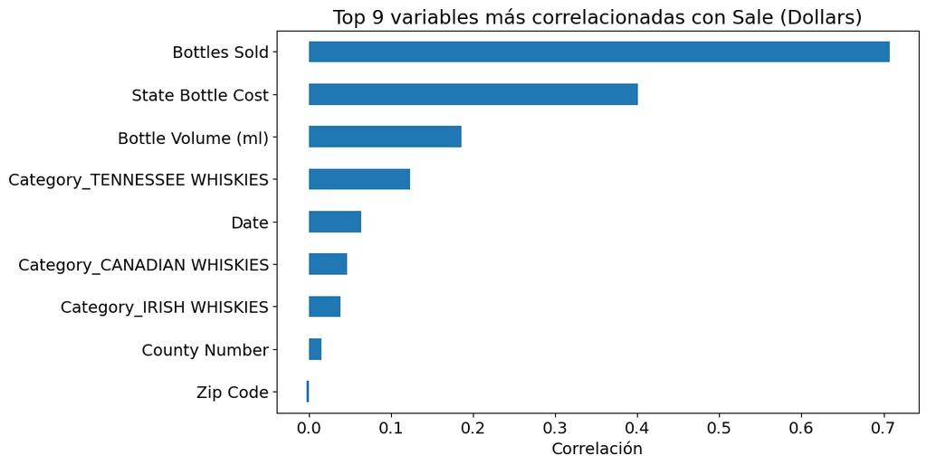

```python
top_corr = correlaciones.drop('Sale (Dollars)').head(9)  # 9 más correlacionadas
plt.figure(figsize=(10, 6))
top_corr.plot(kind='barh')
plt.title('Top 9 variables más correlacionadas con Sale (Dollars)')
plt.xlabel('Correlación')
plt.gca().invert_yaxis()
plt.show()
```

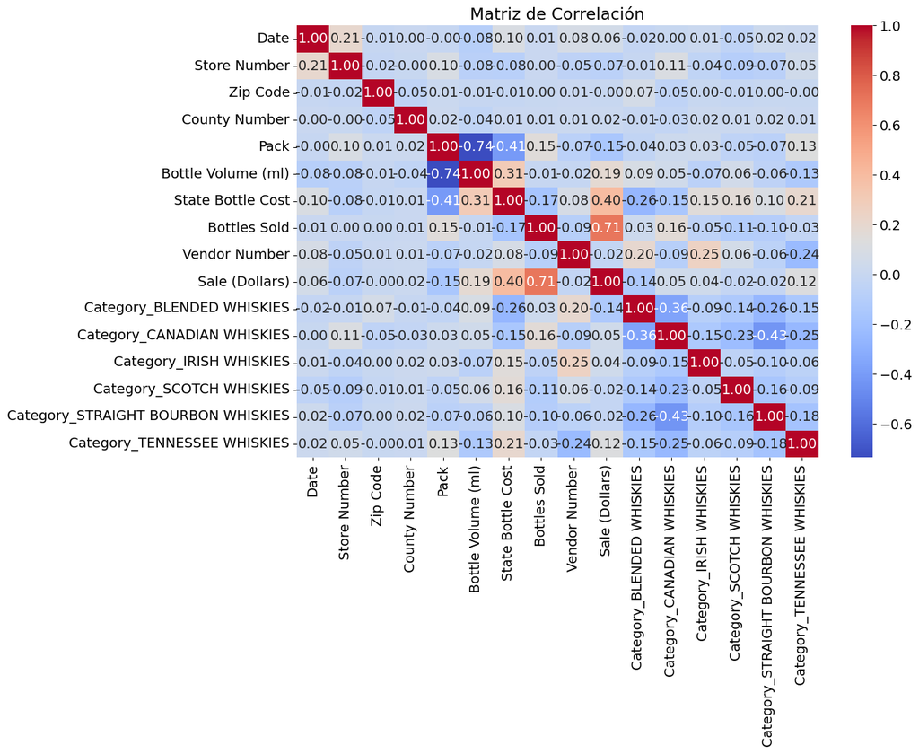

```python
#!pip install seaborn

import seaborn as sns
import matplotlib.pyplot as plt

plt.figure(figsize=(12, 8))
sns.heatmap(data_limpia.corr(numeric_only=True), annot=True, cmap='coolwarm', fmt=".2f")
plt.title('Matriz de Correlación')
plt.show()
```

Además, veamos como se comporta la correlación Sperman y la correlación parcial para verificar la importancia de las variables sea similar a la encontrada por la matriz de correlación.

#### 3.6.1 Correlación de Spearman

```python
data_limpia.corr(method='spearman', min_periods=1, numeric_only=False)
```

|  | Date | Store Number | Zip Code | County Number | Pack | Bottle Volume (ml) | State Bottle Cost | Bottles Sold | Vendor Number | Sale (Dollars) | Category_BLENDED WHISKIES | Category_CANADIAN WHISKIES | Category_IRISH WHISKIES | Category_SCOTCH WHISKIES | Category_STRAIGHT BOURBON WHISKIES | Category_TENNESSEE WHISKIES |
| --- | --- | --- | --- | --- | --- | --- | --- | --- | --- | --- | --- | --- | --- | --- | --- | --- |
| Date | 1.000000 | 0.176256 | -0.012069 | 0.004314 | -0.006320 | -0.087378 | 0.100570 | 0.006730 | 0.057089 | 0.064656 | -0.022787 | 0.006623 | 0.014846 | -0.042847 | 0.020971 | 0.018445 |
| Store Number | 0.176256 | 1.000000 | -0.014317 | 0.022528 | 0.073787 | -0.107330 | -0.086840 | -0.021046 | -0.022472 | -0.068847 | -0.011869 | 0.108431 | -0.041556 | -0.090202 | -0.072632 | 0.049569 |
| Zip Code | -0.012069 | -0.014317 | 1.000000 | -0.091370 | 0.011553 | 0.001939 | -0.017967 | 0.002839 | 0.009648 | -0.006513 | 0.069270 | -0.037665 | -0.003821 | -0.013212 | -0.007075 | -0.003541 |
| County Number | 0.004314 | 0.022528 | -0.091370 | 1.000000 | 0.020620 | -0.044012 | 0.003322 | 0.016405 | 0.008461 | 0.014166 | -0.006851 | -0.026594 | 0.014262 | 0.011167 | 0.018494 | 0.007092 |
| Pack | -0.006320 | 0.073787 | 0.011553 | 0.020620 | 1.000000 | -0.738302 | -0.418085 | 0.061521 | -0.018673 | -0.206310 | -0.064988 | -0.024356 | 0.068551 | -0.022427 | -0.030010 | 0.146698 |
| Bottle Volume (ml) | -0.087378 | -0.107330 | 0.001939 | -0.044012 | -0.738302 | 1.000000 | 0.396792 | 0.126103 | -0.044045 | 0.345218 | 0.080984 | 0.024879 | -0.044822 | 0.080303 | -0.040339 | -0.134069 |
| State Bottle Cost | 0.100570 | -0.086840 | -0.017967 | 0.003322 | -0.418085 | 0.396792 | 1.000000 | -0.145754 | 0.102075 | 0.403577 | -0.259680 | -0.182748 | 0.173346 | 0.172230 | 0.123053 | 0.198312 |
| Bottles Sold | 0.006730 | -0.021046 | 0.002839 | 0.016405 | 0.061521 | 0.126103 | -0.145754 | 1.000000 | -0.046502 | 0.818136 | 0.057239 | 0.147934 | -0.057981 | -0.111474 | -0.093824 | -0.045548 |
| Vendor Number | 0.057089 | -0.022472 | 0.009648 | 0.008461 | -0.018673 | -0.044045 | 0.102075 | -0.046502 | 1.000000 | 0.005692 | 0.202888 | -0.000602 | 0.223054 | 0.021127 | -0.181799 | -0.156937 |
| Sale (Dollars) | 0.064656 | -0.068847 | -0.006513 | 0.014166 | -0.206310 | 0.345218 | 0.403577 | 0.818136 | 0.005692 | 1.000000 | -0.108134 | 0.056671 | 0.026173 | -0.012682 | -0.013626 | 0.062721 |
| Category_BLENDED WHISKIES | -0.022787 | -0.011869 | 0.069270 | -0.006851 | -0.064988 | 0.080984 | -0.259680 | 0.057239 | 0.202888 | -0.108134 | 1.000000 | -0.363159 | -0.087175 | -0.135740 | -0.259785 | -0.151513 |
| Category_CANADIAN WHISKIES | 0.006623 | 0.108431 | -0.037665 | -0.026594 | -0.024356 | 0.024879 | -0.182748 | 0.147934 | -0.000602 | 0.056671 | -0.363159 | 1.000000 | -0.145474 | -0.226517 | -0.433517 | -0.252837 |
| Category_IRISH WHISKIES | 0.014846 | -0.041556 | -0.003821 | 0.014262 | 0.068551 | -0.044822 | 0.173346 | -0.057981 | 0.223054 | 0.026173 | -0.087175 | -0.145474 | 1.000000 | -0.054375 | -0.104065 | -0.060693 |
| Category_SCOTCH WHISKIES | -0.042847 | -0.090202 | -0.013212 | 0.011167 | -0.022427 | 0.080303 | 0.172230 | -0.111474 | 0.021127 | -0.012682 | -0.135740 | -0.226517 | -0.054375 | 1.000000 | -0.162039 | -0.094505 |
| Category_STRAIGHT BOURBON WHISKIES | 0.020971 | -0.072632 | -0.007075 | 0.018494 | -0.030010 | -0.040339 | 0.123053 | -0.093824 | -0.181799 | -0.013626 | -0.259785 | -0.433517 | -0.104065 | -0.162039 | 1.000000 | -0.180867 |
| Category_TENNESSEE WHISKIES | 0.018445 | 0.049569 | -0.003541 | 0.007092 | 0.146698 | -0.134069 | 0.198312 | -0.045548 | -0.156937 | 0.062721 | -0.151513 | -0.252837 | -0.060693 | -0.094505 | -0.180867 | 1.000000 |

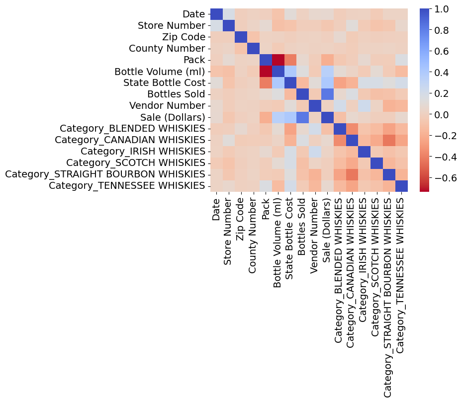

```python
%matplotlib inline
# calculate the correlation matrix
corr = data_limpia.corr(method='spearman', min_periods=1, numeric_only=False)

# plot the heatmap
sns.heatmap(corr,
        xticklabels=corr.columns,
        yticklabels=corr.columns, cmap='coolwarm_r')
plt.show()
```

Las dos gráficas son muy parecidas en este caso, esto probablemente indique que no hay muchos outliers dado el proceso de limpieza de datos por lo que podemos afirmar que el tratamiento que se realizo a los datos ah sido bastante bueno y riguroso.

Sin embargo, las correlaciones no son del todo iguales.

#### **3.6.3 Correlación parcial**

Buscamos las relaciones lineales entre cada par de variables, quitando el efecto de las demás.

```python
from sklearn.linear_model import LinearRegression
from scipy.stats import pearsonr
import numpy as np

feature_num = data_limpia.shape[1]
feature_name = data_limpia.columns
partial_corr_matrix = np.zeros((feature_num, feature_num))
for i in range(feature_num):
    x1 = data_limpia.iloc[:, i]
    for j in range(feature_num):
        if i == j:
            partial_corr_matrix[i, j] = 1
        elif j < i:
            partial_corr_matrix[i, j] = partial_corr_matrix[j, i]
        else:
            x2 = data_limpia.iloc[:, j]
            df_control = data_limpia.drop(columns=[feature_name[i], feature_name[j]], axis=1)
            L = LinearRegression().fit(df_control, x1)
            Lx = L.predict(df_control)
            x1_prime = x1 - Lx

            L = LinearRegression().fit(df_control, x2)
            Lx = L.predict(df_control)
            x2_prime = x2 - Lx
            partial_corr_matrix[i, j] = pearsonr(x1_prime, x2_prime)[0]
```

```python
corrp = pd.DataFrame(partial_corr_matrix, columns=corr.columns)
corrp
```

|  | Date | Store Number | Zip Code | County Number | Pack | Bottle Volume (ml) | State Bottle Cost | Bottles Sold | Vendor Number | Sale (Dollars) | Category_BLENDED WHISKIES | Category_CANADIAN WHISKIES | Category_IRISH WHISKIES | Category_SCOTCH WHISKIES | Category_STRAIGHT BOURBON WHISKIES | Category_TENNESSEE WHISKIES |
| --- | --- | --- | --- | --- | --- | --- | --- | --- | --- | --- | --- | --- | --- | --- | --- | --- |
| 0 | 1.000000 | 2.144985e-01 | -0.004767 | -0.002341 | -6.493390e-02 | -0.130309 | 0.086004 | 0.007013 | 0.070498 | 0.019689 | -0.000016 | -6.524025e-06 | -0.000013 | -6.829549e-05 | -0.000020 | 0.000091 |
| 1 | 0.214499 | 1.000000e+00 | -0.015798 | -0.000034 | 4.089430e-02 | 0.009898 | -0.005693 | 0.023534 | -0.033846 | -0.054480 | 0.000046 | -1.695068e-05 | 0.000008 | 9.165412e-07 | 0.000015 | 0.000028 |
| 2 | -0.004767 | -1.579804e-02 | 1.000000 | -0.049129 | 1.160736e-02 | -0.004116 | -0.001855 | -0.009726 | -0.007558 | 0.012251 | 0.000071 | -3.484275e-05 | 0.000004 | -8.771196e-06 | 0.000021 | -0.000041 |
| 3 | -0.002341 | -3.369966e-05 | -0.049129 | 1.000000 | -6.102685e-03 | -0.035507 | 0.004315 | 0.002697 | 0.004458 | 0.008470 | 0.000024 | 2.773196e-05 | -0.000123 | 9.630146e-06 | -0.000066 | 0.000029 |
| 4 | -0.064934 | 4.089430e-02 | 0.011607 | -0.006103 | 1.000000e+00 | -0.683320 | -0.118333 | 0.183468 | -0.055800 | -0.115918 | 0.000663 | -1.091920e-07 | -0.000031 | -2.603053e-05 | 0.000065 | 0.000143 |
| 5 | -0.130309 | 9.898417e-03 | -0.004116 | -0.035507 | -6.833202e-01 | 1.000000 | 0.097388 | 0.071967 | -0.119903 | -0.005669 | 0.000299 | 2.733730e-04 | 0.000317 | -5.498245e-05 | -0.000006 | 0.000076 |
| 6 | 0.086004 | -5.692831e-03 | -0.001855 | 0.004315 | -1.183328e-01 | 0.097388 | 1.000000 | -0.575991 | 0.082388 | 0.636565 | -0.000014 | 1.251989e-04 | 0.000209 | 1.285242e-04 | -0.000070 | -0.000094 |
| 7 | 0.007013 | 2.353421e-02 | -0.009726 | 0.002697 | 1.834681e-01 | 0.071967 | -0.575991 | 1.000000 | -0.057413 | 0.859901 | 0.000168 | -6.255384e-05 | -0.000269 | -9.164809e-05 | -0.000219 | 0.000234 |
| 8 | 0.070498 | -3.384603e-02 | -0.007558 | 0.004458 | -5.579984e-02 | -0.119903 | 0.082388 | -0.057413 | 1.000000 | 0.033736 | 0.000174 | -4.263836e-05 | 0.000505 | -1.051734e-04 | 0.000038 | 0.000147 |
| 9 | 0.019689 | -5.447955e-02 | 0.012251 | 0.008470 | -1.159180e-01 | -0.005669 | 0.636565 | 0.859901 | 0.033736 | 1.000000 | -0.000247 | 1.230073e-04 | -0.000394 | -5.444289e-04 | -0.000161 | -0.000025 |
| 10 | -0.000016 | 4.647781e-05 | 0.000071 | 0.000024 | 6.631518e-04 | 0.000299 | -0.000014 | 0.000168 | 0.000174 | -0.000247 | 1.000000 | -1.000000e+00 | -1.000000 | -1.000000e+00 | -1.000000 | -1.000000 |
| 11 | -0.000007 | -1.695068e-05 | -0.000035 | 0.000028 | -1.091920e-07 | 0.000273 | 0.000125 | -0.000063 | -0.000043 | 0.000123 | -1.000000 | 1.000000e+00 | -1.000000 | -1.000000e+00 | -1.000000 | -1.000000 |
| 12 | -0.000013 | 7.530062e-06 | 0.000004 | -0.000123 | -3.124494e-05 | 0.000317 | 0.000209 | -0.000269 | 0.000505 | -0.000394 | -1.000000 | -1.000000e+00 | 1.000000 | -1.000000e+00 | -1.000000 | -1.000000 |
| 13 | -0.000068 | 9.165412e-07 | -0.000009 | 0.000010 | -2.603053e-05 | -0.000055 | 0.000129 | -0.000092 | -0.000105 | -0.000544 | -1.000000 | -1.000000e+00 | -1.000000 | 1.000000e+00 | -1.000000 | -1.000000 |
| 14 | -0.000020 | 1.490298e-05 | 0.000021 | -0.000066 | 6.471732e-05 | -0.000006 | -0.000070 | -0.000219 | 0.000038 | -0.000161 | -1.000000 | -1.000000e+00 | -1.000000 | -1.000000e+00 | 1.000000 | -1.000000 |
| 15 | 0.000091 | 2.813364e-05 | -0.000041 | 0.000029 | 1.426517e-04 | 0.000076 | -0.000094 | 0.000234 | 0.000147 | -0.000025 | -1.000000 | -1.000000e+00 | -1.000000 | -1.000000e+00 | -1.000000 | 1.000000 |

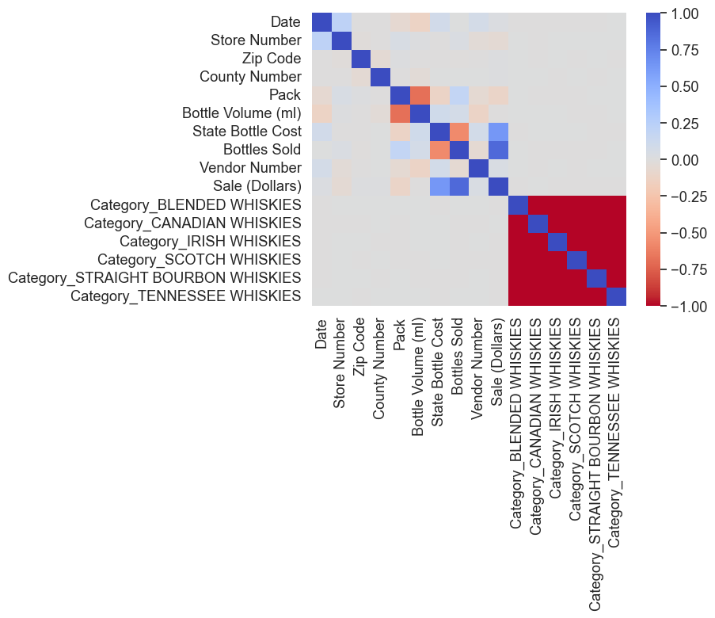

```python
# plot the heatmap
sns.heatmap(corrp,
        xticklabels=corr.columns,
        yticklabels=corr.columns, cmap='coolwarm_r')
```

```python
# Guardar el DataFrame limpio como un archivo CSV
#data_limpia.to_csv('data_limpia.csv', index=False)
```

# 4. Modelación

En esta sección nos encargaremos de entrenar al modelo para predecir *Sale (Dollars)* y escogeremos al mejor modelo con el criterio de que su MAE sea menor a un dolar de error

### **4.1 División y entrenamiento de los datos**

```python
var_salida = "Sale (Dollars)"
data_x = data_limpia.drop(columns=[var_salida])
data_y = data_limpia[var_salida]
```

```python
data_x.head()
```

|  | Date | Store Number | Zip Code | County Number | Pack | Bottle Volume (ml) | State Bottle Cost | Bottles Sold | Vendor Number | Category_BLENDED WHISKIES | Category_CANADIAN WHISKIES | Category_IRISH WHISKIES | Category_SCOTCH WHISKIES | Category_STRAIGHT BOURBON WHISKIES | Category_TENNESSEE WHISKIES |
| --- | --- | --- | --- | --- | --- | --- | --- | --- | --- | --- | --- | --- | --- | --- | --- |
| 0 | 20120327 | 4222 | 50707 | 7.0 | 10 | 600 | 4.96 | 10 | 115.0 | False | True | False | False | False | False |
| 1 | 20120306 | 2591 | 50022 | 15.0 | 12 | 750 | 5.23 | 12 | 115.0 | False | True | False | False | False | False |
| 2 | 20150409 | 2806 | 52732 | 23.0 | 6 | 1750 | 13.71 | 6 | 259.0 | False | False | False | False | True | False |
| 3 | 20130130 | 4197 | 51054 | 97.0 | 12 | 750 | 13.54 | 12 | 85.0 | False | False | False | False | False | True |
| 4 | 20140318 | 4131 | 50322 | 77.0 | 12 | 750 | 12.25 | 12 | 260.0 | False | False | False | True | False | False |

```python
data_y.head()
```

```
0     74.40
1     94.08
2    127.14
3    243.72
4    220.56
Name: Sale (Dollars), dtype: float64
```

```python
from sklearn.model_selection import train_test_split

semilla = 42

# Proporcion de datos en train, validation y test
train_ratio = 0.5
validation_ratio = 0.25
test_ratio = 0.25

x_train, x_val_test, y_train, y_val_test = train_test_split(data_x, data_y, test_size= validation_ratio + test_ratio, random_state = semilla)
x_val, x_test, y_val, y_test = train_test_split(x_val_test, y_val_test, test_size=test_ratio/(test_ratio + validation_ratio), random_state = semilla)
```

```python
x_train.shape
```

```
(1529636, 15)
```

```python
x_train.head()
```

|  | Date | Store Number | Zip Code | County Number | Pack | Bottle Volume (ml) | State Bottle Cost | Bottles Sold | Vendor Number | Category_BLENDED WHISKIES | Category_CANADIAN WHISKIES | Category_IRISH WHISKIES | Category_SCOTCH WHISKIES | Category_STRAIGHT BOURBON WHISKIES | Category_TENNESSEE WHISKIES |
| --- | --- | --- | --- | --- | --- | --- | --- | --- | --- | --- | --- | --- | --- | --- | --- |
| 2288468 | 20131029 | 3816 | 51566 | 69.0 | 12 | 750 | 17.74 | 3 | 370.0 | False | False | False | True | False | False |
| 629864 | 20190920 | 2559 | 52531 | 68.0 | 12 | 750 | 5.23 | 12 | 115.0 | False | True | False | False | False | False |
| 2948016 | 20150723 | 2671 | 50129 | 37.0 | 12 | 1000 | 4.46 | 24 | 65.0 | True | False | False | False | False | False |
| 463132 | 20130501 | 2200 | 50583 | 81.0 | 6 | 1750 | 8.72 | 6 | 55.0 | False | True | False | False | False | False |
| 361110 | 20190327 | 5526 | 50643 | 7.0 | 6 | 1750 | 12.96 | 6 | 260.0 | True | False | False | False | False | False |

```python
y_train.shape
```

```
(1529636,)
```

```python
y_train.head()
```

```
2288468     80.97
629864      94.20
2948016    160.56
463132      78.48
361110     116.64
Name: Sale (Dollars), dtype: float64
```

```python
x_test.shape
```

```
(764818, 15)
```

```python
x_test.head()
```

|  | Date | Store Number | Zip Code | County Number | Pack | Bottle Volume (ml) | State Bottle Cost | Bottles Sold | Vendor Number | Category_BLENDED WHISKIES | Category_CANADIAN WHISKIES | Category_IRISH WHISKIES | Category_SCOTCH WHISKIES | Category_STRAIGHT BOURBON WHISKIES | Category_TENNESSEE WHISKIES |
| --- | --- | --- | --- | --- | --- | --- | --- | --- | --- | --- | --- | --- | --- | --- | --- |
| 1788414 | 20120124 | 4306 | 50441 | 35.0 | 6 | 1750 | 8.32 | 6 | 55.0 | False | True | False | False | False | False |
| 2307571 | 20141229 | 3820 | 51103 | 97.0 | 12 | 750 | 13.01 | 1 | 260.0 | False | False | False | False | False | True |
| 1412304 | 20160915 | 2623 | 51104 | 97.0 | 12 | 750 | 15.59 | 12 | 260.0 | False | True | False | False | False | False |
| 15800 | 20150304 | 3818 | 50138 | 63.0 | 12 | 1000 | 22.04 | 1 | 65.0 | False | False | False | False | True | False |
| 2356311 | 20140508 | 4856 | 52253 | 57.0 | 12 | 750 | 14.00 | 3 | 260.0 | False | False | False | True | False | False |

```python
y_test.shape
```

```
(764818,)
```

```python
y_test.head()
```

```
1788414     74.88
2307571     19.52
1412304    271.32
15800       33.06
2356311     62.97
Name: Sale (Dollars), dtype: float64
```

### **4.2 Entrenamiento de modelos para la predicción**

```python
from sklearn import tree
from sklearn.tree import DecisionTreeRegressor
from sklearn.metrics import mean_absolute_percentage_error, mean_squared_error, mean_absolute_error
from sklearn.base import clone
from joblib import Parallel, delayed
```

#### **4.2.1 Arboles de desición**

```python
# Primer for (evalúa en total 150 modelos)

# Rango de hiperparámetros
max_depth_range = range(5, 10)               # 5 valores
min_samples_split_range = range(2, 14, 2)    # 6 valores
min_samples_leaf_range = range(5, 10)        # 5 valores

print(f"Evaluando {len(max_depth_range) * len(min_samples_split_range) * len(min_samples_leaf_range)} modelos...")


# Función para evaluar un modelo
def evaluar_dtr(max_depth, min_split, min_leaf):
    try:
        modelo = DecisionTreeRegressor(
            random_state=semilla,
            max_depth=max_depth,
            min_samples_split=min_split,
            min_samples_leaf=min_leaf
        )
        modelo.fit(x_train, y_train)
        predicciones = modelo.predict(x_val)
        mae = mean_absolute_error(y_val, predicciones)
        return (mae, clone(modelo))
    except Exception as e:
        print(f"Error en: depth={max_depth}, split={min_split}, leaf={min_leaf} → {e}")
        return None

# Ejecutar en paralelo todas las combinaciones
resultados_dtr = Parallel(n_jobs=-1)(
    delayed(evaluar_dtr)(i, j, k)
    for i in max_depth_range
    for j in min_samples_split_range
    for k in min_samples_leaf_range
)

#Seleccionar el del mejor MAE
min_mae1, dtr1 = min(resultados_dtr, key=lambda x: x[0])

    # Reentrenar con todos los datos
dtr1.fit(x_train, y_train)
```

```
Evaluando 150 modelos...
```

```
DecisionTreeRegressor(max_depth=9, min_samples_leaf=9, random_state=42)
```

```python
# Define los valores a evaluar
depth_values = range(6, 11)
feature_values = ['sqrt', 'log2', None, 0.5, 0.8]
alpha_values = [0.0, 0.01, 0.02, 0.03, 0.05, 0.1]

print(f"Evaluando {len(alpha_values) * len(feature_values) * len(alpha_values)} modelos...")


# Función para evaluar un solo modelo
def evaluar_modelo(max_depth, max_features, ccp_alpha):
    modelo = DecisionTreeRegressor(
        random_state=semilla,
        max_depth=max_depth,
        max_features=max_features,
        ccp_alpha=ccp_alpha
    )
    modelo.fit(x_train, y_train)
    predicciones = modelo.predict(x_val)
    mae = mean_absolute_error(y_val, predicciones)
    return (mae, clone(modelo))

# Ejecutar en paralelo
resultados = Parallel(n_jobs=-1)(
    delayed(evaluar_modelo)(i, j, k)
    for i in depth_values
    for j in feature_values
    for k in alpha_values
)

# Seleccionar el modelo con menor MAE
min_mae2, dtr2 = min(resultados, key=lambda x: x[0])

# Reentrenar el mejor modelo con todo el set de entrenamiento
dtr2.fit(x_train, y_train)
```

```
Evaluando 180 modelos...
```

```
DecisionTreeRegressor(max_depth=10, random_state=42)
```

```python
pred_val1 = dtr1.predict(x_val)
print("Metricas mejor árbol 1: ")
print("MSE: " +  str(mean_squared_error(y_val, pred_val1)))
print("MAE: " + str(mean_absolute_error(y_val, pred_val1)))
print("MAPE: "+ str(mean_absolute_percentage_error(y_val, pred_val1)))
```

```
Metricas mejor árbol 1:
MSE: 19.007987907504017
MAE: 1.3515385351519469
MAPE: 0.024215615315658107
```

```python
pred_val2 = dtr2.predict(x_val)
print("Metricas mejor árbol 2: ")
print("MSE: " +  str(mean_squared_error(y_val, pred_val2)))
print("MAE: " + str(mean_absolute_error(y_val, pred_val2)))
print("MAPE: "+ str(mean_absolute_percentage_error(y_val, pred_val2)))
```

```
Metricas mejor árbol 2:
MSE: 15.533907673872596
MAE: 0.8402940681153099
MAPE: 0.014720105151997181
```

Por lo tanto, de los árboles de decisión nos quedaremos con el #2, el cual tiene menores métricas.

#### **4.2.2 Random forest**

```python
from sklearn.ensemble import RandomForestRegressor
```

```python
# — Parámetros —
max_depth_range         = range(40, 43)
n_estimators_range      = range(60, 80,4)
min_samples_split_range = range(3, 5)

# Calculamos el total de combinaciones
total_models = (
    len(max_depth_range)
    * len(n_estimators_range)
    * len(min_samples_split_range)
)
print(f"Total de modelos a entrenar: {total_models}")

def evaluar_rf1(max_depth, n_estimators, min_samples_split):
    modelo = RandomForestRegressor(
        random_state=semilla,
        max_depth=max_depth,
        n_estimators=n_estimators,
        min_samples_split=min_samples_split,
        n_jobs=2
    )
    modelo.fit(x_train, y_train)
    predicciones = modelo.predict(x_val)
    mae = mean_absolute_error(y_val, predicciones)
    return (mae, clone(modelo))

# Ejecutar en paralelo
resultados_rf1 = Parallel(n_jobs=-1)(
    delayed(evaluar_rf1)(i, j, k)
    for i in max_depth_range
    for j in n_estimators_range
    for k in min_samples_split_range
)

_, rf1 = min(resultados_rf1, key=lambda x: x[0])

# Ahora sí puedes reentrenar sin error
rf1.fit(x_train, y_train)
```

[output not shown]

```
RandomForestRegressor(max_depth=41, min_samples_split=3, n_estimators=76,
                      n_jobs=2, random_state=42)
```

```python
# Definición de rangos de hiperparámetros
max_depth_range = range(7, 12)
n_estimators_range = range(10, 20)
min_samples_leaf_range = range(3,6)

print(f"Evaluando {len(max_depth_range) * len(min_samples_leaf_range) * len(n_estimators_range)} modelos...")

# Función para evaluar un solo modelo
def evaluar_rf(max_depth, n_estimators, min_samples_leaf):
    modelo = RandomForestRegressor(
        random_state=semilla,
        max_depth=max_depth,
        n_estimators=n_estimators,
        min_samples_leaf=min_samples_leaf,
        n_jobs=2
    )
    modelo.fit(x_train, y_train)
    predicciones = modelo.predict(x_val)
    mae = mean_absolute_error(y_val, predicciones)
    return (mae, clone(modelo))

# Ejecutar en paralelo todas las combinaciones
resultados_rf = Parallel(n_jobs=-1)(
    delayed(evaluar_rf)(i, j, k)
    for i in max_depth_range
    for j in n_estimators_range
    for k in min_samples_leaf_range
)

# Seleccionar el modelo con menor MAE
min_mae1, rf2 = min(resultados_rf, key=lambda x: x[0])

# Reentrenar el mejor modelo con todos los datos de entrenamiento
rf2.fit(x_train, y_train)
```

```
Evaluando 150 modelos...
```

```
RandomForestRegressor(max_depth=11, min_samples_leaf=3, n_estimators=19,
                      n_jobs=2, random_state=42)
```

```python
pred_val1 = rf1.predict(x_val)
print("Metricas mejor random forest 1: ")
print("MSE: " +  str(mean_squared_error(y_val, pred_val1)))
print("MAE: " + str(mean_absolute_error(y_val, pred_val1)))
print("MAPE: "+ str(mean_absolute_percentage_error(y_val, pred_val1)))
```

```
Metricas mejor random forest 1:
MSE: 9.69856848540296
MAE: 0.13088736928232167
MAPE: 0.003377570657279555
```

```python
pred_val2 = rf2.predict(x_val)
print("Metricas random forest 2: ")
print("MSE: " +  str(mean_squared_error(y_val, pred_val2)))
print("MAE: " + str(mean_absolute_error(y_val, pred_val2)))
print("MAPE: "+ str(mean_absolute_percentage_error(y_val, pred_val2)))
```

```
Metricas random forest 2:
MSE: 12.178389340215068
MAE: 0.5217685843083973
MAPE: 0.00944705552946948
```

Por lo tanto, de los random forest nos quedaremos con el #1, el cual tiene menores métricas.

#### **4.2.3 Gradient Boosting**

```python
from sklearn.ensemble import HistGradientBoostingRegressor
```

```python
# Rangos corregidos
max_depth_range     = [5, 7, 10, 12, 15]
learning_rate_range = [0.02, 0.03, 0.05, 0.1, 0.15]
max_iter_range      = [100, 300, 500, 700, 1000]

print(f"Evaluando {len(max_depth_range) * len(learning_rate_range) * len(max_iter_range)} modelos...")

def evaluar_gb1(max_depth, learning_rate, max_iter):
    modelo = HistGradientBoostingRegressor(
        random_state=semilla,
        max_iter=max_iter,
        learning_rate=learning_rate,
        max_depth=max_depth,
        min_samples_leaf=60,
        max_iter_no_change=300,
        early_stopping=True,
        max_features=0.8
    )
    modelo.fit(x_train, y_train)
    predicciones = modelo.predict(x_val)
    mae = mean_absolute_error(y_val, predicciones)
    return mae, clone(modelo)

# Ahora sí iteramos sobre los rangos correctos
resultados_gb1 = Parallel(n_jobs=-1)(
    delayed(evaluar_gb1)(d, lr, it)
    for d  in max_depth_range
    for lr in learning_rate_range
    for it in max_iter_range
)

# Seleccionamos y reentrenamos el mejor
min_mae1, gb1 = min(resultados_gb1, key=lambda x: x[0])
gb1.fit(x_train, y_train)
```

```
Evaluando 125 modelos...
```

[output not shown]

```python
pred_val1 = gb1.predict(x_val)
print("Metricas gradient boosting 1: ")
print("MSE: " +  str(mean_squared_error(y_val, pred_val1)))
print("MAE: " + str(mean_absolute_error(y_val, pred_val1)))
print("MAPE: "+ str(mean_absolute_percentage_error(y_val, pred_val1)))
```

```
Metricas gradient boosting 1:
MSE: 11.16470083115123
MAE: 0.40031211457092536
MAPE: 0.008924377403739286
```

#### **4.2.4 Modelo escogido**

Las mejores métricas las presenta el random forest *rf1*, por lo que nos quedaremos con este modelo para realizar la predicción.

```python
modelo_final = clone(rf1)
```

```python
modelo_final.set_params(n_jobs=-1)  # Activar uso de todos los núcleos

# Combinar los datos de entrenamiento y validación
x_train_val = pd.concat([x_train, x_val])
y_train_val = pd.concat([y_train, y_val])

# Entrenar el modelo final
modelo_final.fit(x_train_val, y_train_val)
```

```
RandomForestRegressor(max_depth=41, min_samples_split=3, n_estimators=76,
                      n_jobs=-1, random_state=42)
```

#### **4.2.5 Metricas del modelo escogido**

```python
pred_test = modelo_final.predict(x_test)
print("Metricas modelo elegido en test: ")
print("MSE: " +  str(mean_squared_error(y_test, pred_test)))
print("MAE: " + str(mean_absolute_error(y_test, pred_test)))
print("MAPE: "+ str(mean_absolute_percentage_error(y_test, pred_test)))
```

```
Metricas modelo elegido en test:
MSE: 9.448727286614789
MAE: 0.1155178905513807
MAPE: 0.0029281052110591193
```

Vemos que las métricas son relativamente parecidas a las de validación, lo cual indica que el modelo está generalizando correctamente con nuevos datos que no ha visto.

Estas métricas de test (prueba) son las que sí representan realmente cómo se comportara nuestro modelo a futuro, y son muy importantes para el Negocio puesto que nos ayudan a saber qué esperamos que pase en el futuro (ejemplo: el MAE nos dirá en promedio 11 centavos al predecir el precio de los Whiskys.

# **5 Evaluación**

```python
err_abs = abs(pred_test - y_test)
err_abs
```

```
1788414    7.105427e-14
2307571    1.421085e-14
1412304    5.684342e-14
15800      1.065814e-13
2356311    3.481659e-13
               ...
1658610    2.557954e-13
2093954    1.065814e-13
1558364    1.136868e-13
2473077    7.247536e-13
1943978    4.263256e-14
Name: Sale (Dollars), Length: 764818, dtype: float64
```

```python
err_abs.mean()
```

```
np.float64(0.1155178905513807)
```

```python
# Dejar solo las filas que correspondían a indices que están en test
data_test = data_limpia[data_limpia.index.isin(x_test.index)].copy()

# Pegarle los errores absolutos de predicción
data_test["Error absoluto"] = err_abs
data_test.head()
```

|  | Date | Store Number | Zip Code | County Number | Pack | Bottle Volume (ml) | State Bottle Cost | Bottles Sold | Vendor Number | Sale (Dollars) | Category_BLENDED WHISKIES | Category_CANADIAN WHISKIES | Category_IRISH WHISKIES | Category_SCOTCH WHISKIES | Category_STRAIGHT BOURBON WHISKIES | Category_TENNESSEE WHISKIES | Error absoluto |
| --- | --- | --- | --- | --- | --- | --- | --- | --- | --- | --- | --- | --- | --- | --- | --- | --- | --- |
| 1 | 20120306 | 2591 | 50022 | 15.0 | 12 | 750 | 5.23 | 12 | 115.0 | 94.08 | False | True | False | False | False | False | 6.536993e-13 |
| 3 | 20130130 | 4197 | 51054 | 97.0 | 12 | 750 | 13.54 | 12 | 85.0 | 243.72 | False | False | False | False | False | True | 6.053824e-12 |
| 5 | 20120716 | 4277 | 51031 | 75.0 | 12 | 1000 | 7.50 | 12 | 260.0 | 134.88 | True | False | False | False | False | False | 2.927436e-12 |
| 9 | 20150601 | 2841 | 52403 | 57.0 | 12 | 750 | 5.23 | 12 | 115.0 | 94.20 | False | True | False | False | False | False | 1.482192e-11 |
| 11 | 20141217 | 2290 | 50588 | 11.0 | 6 | 1750 | 31.99 | 3 | 260.0 | 143.97 | False | True | False | False | False | False | 3.126388e-13 |

```python
data_test.describe(include="all")
```

|  | Date | Store Number | Zip Code | County Number | Pack | Bottle Volume (ml) | State Bottle Cost | Bottles Sold | Vendor Number | Sale (Dollars) | Category_BLENDED WHISKIES | Category_CANADIAN WHISKIES | Category_IRISH WHISKIES | Category_SCOTCH WHISKIES | Category_STRAIGHT BOURBON WHISKIES | Category_TENNESSEE WHISKIES | Error absoluto |
| --- | --- | --- | --- | --- | --- | --- | --- | --- | --- | --- | --- | --- | --- | --- | --- | --- | --- |
| count | 7.648180e+05 | 764818.000000 | 764818.000000 | 764818.000000 | 764818.000000 | 764818.000000 | 764818.000000 | 764818.000000 | 764818.000000 | 764818.000000 | 764818 | 764818 | 764818 | 764818 | 764818 | 764818 | 7.648180e+05 |
| unique | NaN | NaN | NaN | NaN | NaN | NaN | NaN | NaN | NaN | NaN | 2 | 2 | 2 | 2 | 2 | 2 | NaN |
| top | NaN | NaN | NaN | NaN | NaN | NaN | NaN | NaN | NaN | NaN | False | False | False | False | False | False | NaN |
| freq | NaN | NaN | NaN | NaN | NaN | NaN | NaN | NaN | NaN | NaN | 627751 | 476064 | 739021 | 705085 | 584152 | 692017 | NaN |
| mean | 2.015289e+07 | 3655.827545 | 51248.403499 | 56.562529 | 11.324732 | 979.016542 | 10.667644 | 7.453669 | 183.035975 | 109.412744 | NaN | NaN | NaN | NaN | NaN | NaN | 1.155179e-01 |
| std | 2.635251e+04 | 964.395164 | 975.389673 | 27.466199 | 5.103758 | 498.116724 | 6.089401 | 6.397671 | 126.234220 | 106.810174 | NaN | NaN | NaN | NaN | NaN | NaN | 3.071709e+00 |
| min | 2.012010e+07 | 2106.000000 | 50002.000000 | 1.000000 | 1.000000 | 50.000000 | 1.870000 | 1.000000 | 35.000000 | 2.800000 | NaN | NaN | NaN | NaN | NaN | NaN | 0.000000e+00 |
| 25% | 2.013090e+07 | 2614.000000 | 50316.000000 | 31.000000 | 6.000000 | 750.000000 | 6.630000 | 3.000000 | 65.000000 | 34.200000 | NaN | NaN | NaN | NaN | NaN | NaN | 1.776357e-14 |
| 50% | 2.015041e+07 | 3762.000000 | 51050.000000 | 60.000000 | 12.000000 | 750.000000 | 9.180000 | 6.000000 | 115.000000 | 80.940000 | NaN | NaN | NaN | NaN | NaN | NaN | 1.918465e-13 |
| 75% | 2.016102e+07 | 4382.000000 | 52247.000000 | 77.000000 | 12.000000 | 1750.000000 | 14.040000 | 12.000000 | 260.000000 | 132.840000 | NaN | NaN | NaN | NaN | NaN | NaN | 1.605827e-12 |
| max | 2.022072e+07 | 6342.000000 | 52807.000000 | 99.000000 | 24.000000 | 1750.000000 | 40.000000 | 54.000000 | 578.000000 | 935.520000 | NaN | NaN | NaN | NaN | NaN | NaN | 3.235365e+02 |

```python
data_test.shape
```

```
(764818, 17)
```

Ahora si podemos comenzar a hacer las visualizaciones con este conjunto:

### **5.1 Visualizaciones de los errores**

#### **5.1.1 Visualización del error absoluto para Bottle Volume (ml)**

```python
import matplotlib.pyplot as plt
%matplotlib inline
```

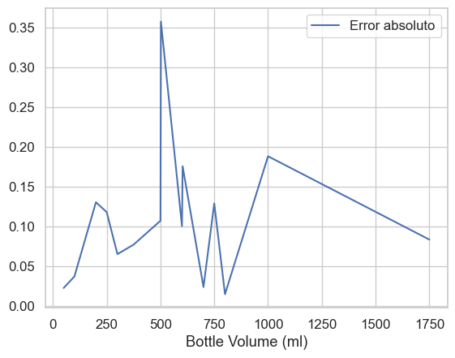

```python
data_1_means = data_test.groupby('Bottle Volume (ml)', as_index=False)['Error absoluto'].mean()
data_1_means = data_1_means.sort_values(by="Bottle Volume (ml)")
data_1_means.plot.line(x = "Bottle Volume (ml)", y = "Error absoluto")
plt.show(1)
```

#### **5.1.2 Visualización del error absoluto por fecha de compra**

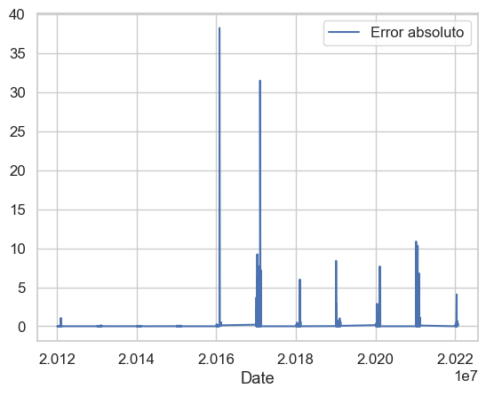

```python
data_2_means = data_test.groupby('Date', as_index=False)['Error absoluto'].mean()
data_2_means = data_2_means.sort_values(by="Date")
data_2_means.plot.line(x = "Date", y = "Error absoluto")
plt.show(1)
```

El error absoluto es casi nulo en la mayor parte del periodo, pero aparecen picos muy pronunciados alrededor de 2016 (≈38 USD) y 2017 (≈31 USD), y otros más moderados en 2020–2021 (5–11 USD).

#### **5.1.3 Visualización del error absoluto para la cantidad de botellas del licor que contiene cada caja**

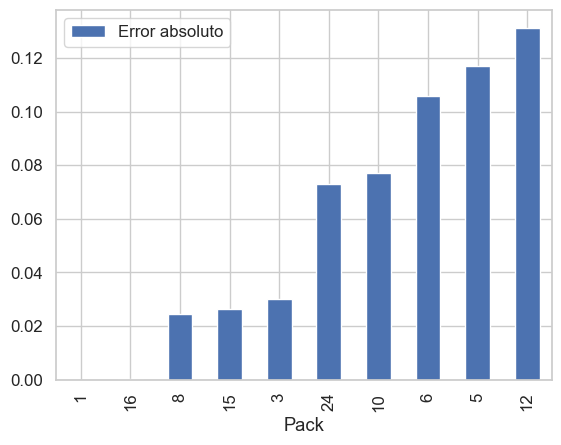

```python
data_3_means = data_test.groupby('Pack', as_index=False)['Error absoluto'].mean()
data_3_means = data_3_means.sort_values(by="Error absoluto")
data_3_means.plot.bar(x = "Pack", y = "Error absoluto")
plt.show()
```

#### **5.1.4 Visualización del error absoluto para Botellas vendidas**

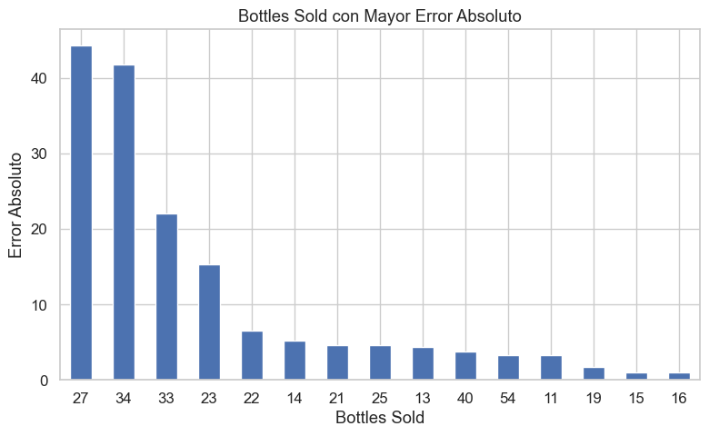

```python
import matplotlib.pyplot as plt

# 1) Agrupo y calculo la media
df = (
    data_test
    .groupby('Bottles Sold', as_index=False)['Error absoluto']
    .mean()
)

# 2) Ordeno de mayor a menor y me quedo con los 10 primeros
df_top10 = df.sort_values('Error absoluto', ascending=False).head(15)

# 3) Grafico igual que antes
fig, ax = plt.subplots(figsize=(8,5))
df_top10.plot.bar(
    x='Bottles Sold',
    y='Error absoluto',
    ax=ax,
    legend=False
)

# 4) Etiquetas y formato
ax.set_title('Bottles Sold con Mayor Error Absoluto')
ax.set_xlabel('Bottles Sold')
ax.set_ylabel('Error Absoluto')
plt.xticks(rotation=0)
plt.tight_layout()
plt.show()
```

#### **5.1.5 Visualización del error absoluto para el condado**

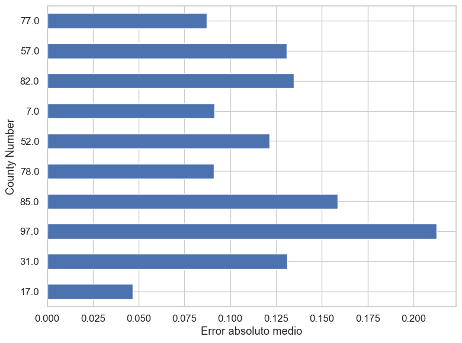

```python
# 1) Cuenta cuántas veces aparece cada County Number y coge los 10 primeros
top10_count = data_test['County Number'].value_counts().head(10)

# 2) Calcula el error absoluto medio por condado
means = data_test.groupby('County Number')['Error absoluto'].mean()

# 3) Selecciona sólo los 10 condados más frecuentes y ordénalos según frecuencia
top10_means = means.loc[top10_count.index]

# 4) Gráfica horizontal
fig, ax = plt.subplots(figsize=(8, 6))
top10_means.plot.barh(ax=ax)
ax.set_xlabel('Error absoluto medio')
ax.set_ylabel('County Number')
ax.invert_yaxis()    # para que el condado más frecuente quede arriba
plt.tight_layout()
plt.show()
```

El MAE por condado varía de forma notable: el menor error medio se da en el condado 17 (≈ 0,05 ), mientras que el más alto ocurre en el condado 97 (≈ 0,21 ); el resto de condados se sitúa entre ≈ 0,09 y 0,16 , mostrando que la precisión del modelo depende fuertemente de la región.

### **5.2 Residuos**

```python
res = (pred_test - y_test).values
res
```

```
array([ 7.10542736e-14, -1.42108547e-14,  5.68434189e-14, ...,
       -1.13686838e-13, -7.24753590e-13,  4.26325641e-14], shape=(764818,))
```

En el caso anterior, los negativos indican que nuestra predicción de precio fue menor que el precio real, mientras que los positivos indican lo contrario.

Ahora, los residuos absolutos:

```python
res_abs = np.abs(res)
res_abs
```

```
array([7.10542736e-14, 1.42108547e-14, 5.68434189e-14, ...,
       1.13686838e-13, 7.24753590e-13, 4.26325641e-14], shape=(764818,))
```

```python
res_abs.mean()  #Este es el MAE
```

```
np.float64(0.1155178905513807)
```

Miremos primero la evolución de los residuales y de sus valores absolutos con boxplots e histogramas:

#### **5.2.1 Histograma de residuales**

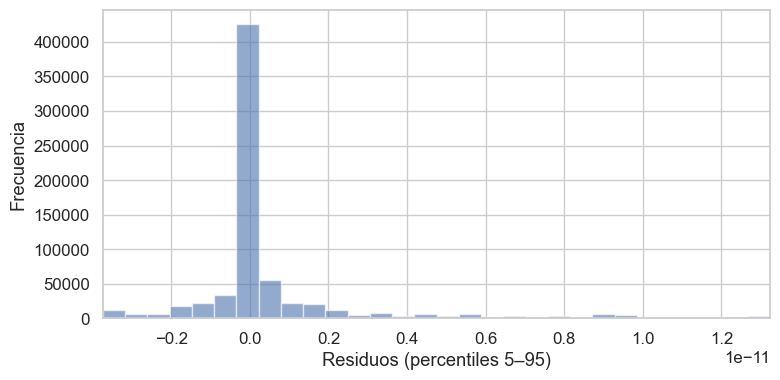

```python
import numpy as np
import matplotlib.pyplot as plt


p_low, p_high = np.percentile(res, [5, 95])

# 2) filtra solo los residuos dentro de esos límites
res_filtrados = res[(res >= p_low) & (res <= p_high)]

# 3) grafícalos
fig, ax = plt.subplots(figsize=(8, 4))
ax.hist(res_filtrados, bins=30, alpha=0.6)
ax.set_xlim(p_low, p_high)
ax.set_xlabel('Residuos (percentiles 5–95)')
ax.set_ylabel('Frecuencia')
plt.tight_layout()
plt.show()
```

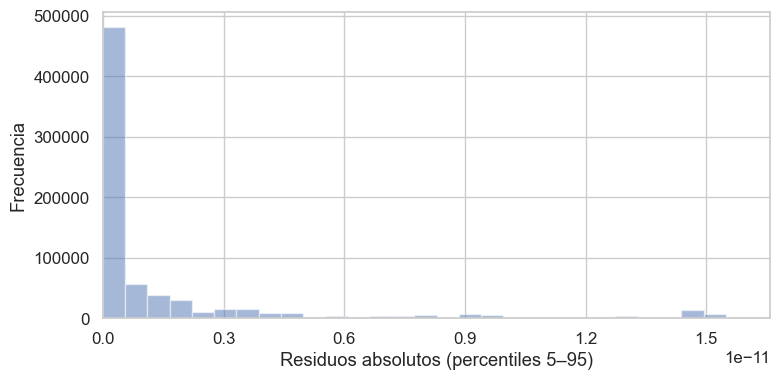

```python
import numpy as np
import matplotlib.pyplot as plt
import pandas as pd

# 2) Calcula percentiles 5 y 95
p_low, p_high = np.percentile(res_abs, [5, 95])

# Filtra solo los residuos dentro de ese rango
res_abs_filtrados = res_abs[(res_abs >= p_low) & (res_abs <= p_high)]


DF2 = pd.DataFrame({'Residuos absolutos (5–95 pct)': res_abs_filtrados})

# 5) Grafica el histograma recortado
fig, ax = plt.subplots(figsize=(8, 4))
DF2.plot.hist(
    bins=30,
    alpha=0.5,
    ax=ax,
    legend=False
)

#Ajusta límites y ticks
ax.set_xlim(p_low, p_high)
ax.xaxis.set_major_locator(plt.MaxNLocator(nbins=6))
ax.set_xlabel('Residuos absolutos (percentiles 5–95)')
ax.set_ylabel('Frecuencia')
plt.tight_layout()
plt.show()
```

```python
np.median(res_abs)
```

```
np.float64(1.9184653865522705e-13)
```

#### **5.2.2 Boxplot de residuales**

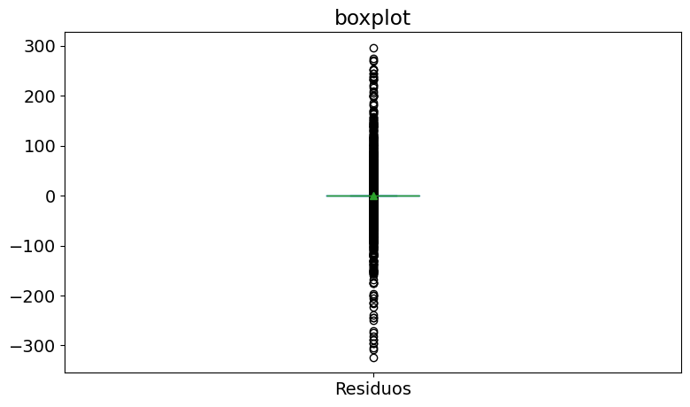

```python
DF = pd.DataFrame({'Residuos': res})
ax = DF.plot(kind='box', title='boxplot', showmeans=True, figsize=(9,5))
plt.show(1)
```

Dado que la anterior visualización no estan clara, la realizamos nuevamente con el eje Y recortado

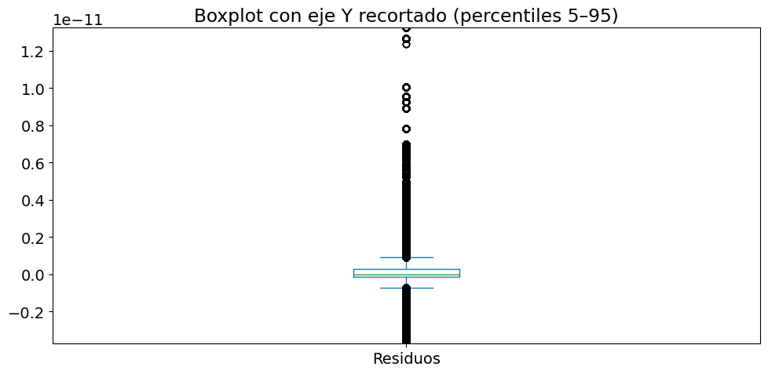

```python
import numpy as np
import matplotlib.pyplot as plt

p5, p95 = np.percentile(res, [5, 95])

fig, ax = plt.subplots(figsize=(10, 5))
DF.plot(kind='box', showmeans=True, ax=ax)
ax.set_ylim(p5, p95)
ax.set_title('Boxplot con eje Y recortado (percentiles 5–95)')
plt.tight_layout()
plt.show()
```

- La **caja** está casi centrada en **cero**, indicando **ausencia de sesgo** sistemático en las predicciones.
- Los **bigotes** cubren un rango muy pequeño en comparación con la nube de puntos, lo que significa que la mayoría de los residuos pequeños quedan agrupados dentro de la caja.
- Hay una gran **cantidad de outliers** en ambos extremos, señalando casos aislados donde el error de predicción es mucho mayor.
- La **dispersión interna** (ancho de la caja) es reducida, lo que confirma que el modelo acierta con **alta precisión** en la mayoría de las observaciones.

#### **5.2.3 Boxplot de residuos absolutos**

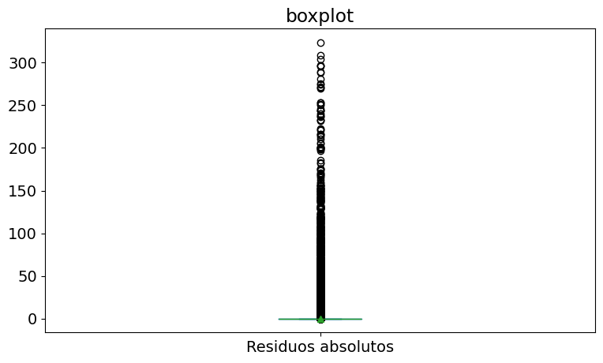

```python
DF = pd.DataFrame({'Residuos absolutos': res_abs})
ax = DF.plot(kind='box', title='boxplot', showmeans=True, figsize=(9,5))
plt.show()
```

- La **mediana** de los residuos absolutos está muy cerca de cero, indicando que la mitad de los errores son prácticamente insignificantes.
- La **caja** es muy estrecha, mostrando que la mayoría de los errores se concentran en un rango muy pequeño.
- Aparecen multitud de **outliers** hacia arriba, lo que revela casos puntuales con errores absolutos elevados.
- La gran cantidad de puntos externos sugiere que, aunque el modelo es muy preciso en la mayoría de los casos, existen observaciones aisladas con desviaciones considerables.

### **5.3 Test de normalidad**

Apliquemos tests de normalidad a los residuos en cada escenario para ver si se ajustan o no a esta distribución y poder así saber qué fórmulas usar más adelante en los intervalos de confianza.

La hipótesis nula en esta prueba es que los datos son normales, y la alternativa que no lo son.

```python
# Residuos
from scipy import stats

k2, p = stats.normaltest(res)
print("p = {:g}".format(p))
```

```
p = 0
```

```python
### Residuos absolutos

k2, p = stats.normaltest(res_abs)

print("p = {:g}".format(p))
```

```
p = 0
```

Con un nivel de confianza muy alto se puede afirmar que hay evdencia suficiente para rechazar la hipótesis nula. Por lo tanto, los datos no provienen de la distribución normal. Podemos visualizarlo en el siguiente gráfico Q-Q plot

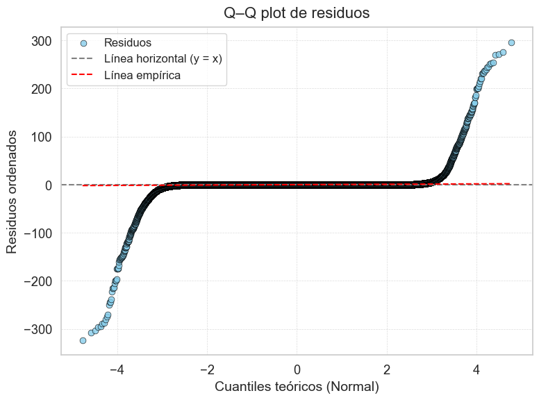

```python
import numpy as np
import scipy.stats as stats
import matplotlib.pyplot as plt

# Supón que ya tienes 'res' con tus residuos
resid = np.asarray(res)

# 1) cuantiles teóricos y residuos ordenados
osm, osr = stats.probplot(resid, dist='norm', fit=False)

# 2) figura y scatter
fig, ax = plt.subplots(figsize=(8, 6))
ax.scatter(osm, osr,
           s=40, facecolor='#87CEEB', edgecolor='black',
           linewidth=0.5, alpha=0.8, label='Residuos')

y_med = np.median(resid)


# 3) línea horizontal en y=x
ax.axhline(y_med,
           linestyle='--', linewidth=1.5, color='gray',
           label='Línea horizontal (y = x)')

# 4) línea empírica de regresión (opcional)
slope, intercept = np.polyfit(osm, osr, 1)
ax.plot(osm, slope*osm + intercept,
        linestyle='--', linewidth=1.5, color='red',
        label='Línea empírica')

# 5) estética
ax.set_title('Q–Q plot de residuos', fontsize=16, pad=10)
ax.set_xlabel('Cuantiles teóricos (Normal)', fontsize=14)
ax.set_ylabel('Residuos ordenados', fontsize=14)
ax.grid(True, linestyle='--', linewidth=0.5, alpha=0.7)
ax.legend(frameon=True, fontsize=12)

plt.tight_layout()
plt.show()
```

### **5.4 Intervalos de confianza**

```python
import numpy as np
import matplotlib.pyplot as plt
from scipy.stats import norm
```

#### **5.4.1 Intervalo de confianza para el MAE los residuos**

Teniendo en cuenta que n ≥ 30, por el teorema del límite central un intervalo de confianza al 99% para el MAE es:

```python
# MAE

x = res_abs.copy() # Aqui se pone la muestra a usar
confidence = 0.99
alfa = 1-confidence

m = x.mean()
s = x.std()

Z_crit = np.abs(norm.ppf(1-(alfa/2)))
# Z_crit = 1.96 ----> percentil del 1.96 de la distribución (el 99% de los datos tienen un valor superior a 1.6)

out= (m-(s*Z_crit/np.sqrt(len(x))), m+(s*Z_crit/np.sqrt(len(x))))
#out = tuple(round(val, 5) for val in out)   # <-- redondea a 2 decimales
out
```

```
(np.float64(0.10647061549589763), np.float64(0.12456516560686377))
```

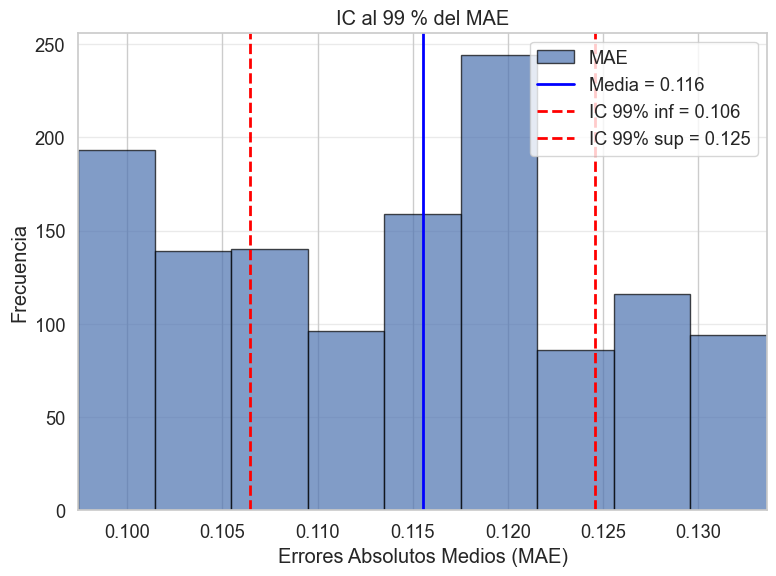

```python
# —————— Datos y cálculo del IC ——————
x = res_abs.copy()
confidence = 0.99
alfa = 1 - confidence

m = x.mean()
s = x.std(ddof=0)
n = len(x)
Z_crit = abs(norm.ppf(1 - alfa/2))
lower = m - Z_crit * s / np.sqrt(n)
upper = m + Z_crit * s / np.sqrt(n)

# —————— Definir margen y zoom ——————
delta = upper - lower
# margen extra: 50% del ancho del IC
margen = delta * 0.5
xmin_zoom = max(0, lower - margen)
xmax_zoom = upper + margen

# —————— Plot zoom ——————
fig, ax = plt.subplots(figsize=(8, 6))

# histogram ajustado al zoom
bins_zoom = np.linspace(xmin_zoom, xmax_zoom, 10)
ax.hist(x, bins=bins_zoom, alpha=0.7, edgecolor='black', label='MAE')

# líneas de media e IC
ax.axvline(m,     color='blue', linestyle='-',  linewidth=2, label=f'Media = {m:.3f}')
ax.axvline(lower, color='red',  linestyle='--', linewidth=2, label=f'IC 99% inf = {lower:.3f}')
ax.axvline(upper, color='red',  linestyle='--', linewidth=2, label=f'IC 99% sup = {upper:.3f}')

# aplicar zoom
ax.set_xlim(xmin_zoom, xmax_zoom)

# etiquetas y estilo
ax.set_title('IC al 99 % del MAE')
ax.set_xlabel('Errores Absolutos Medios (MAE)')
ax.set_ylabel('Frecuencia')
ax.legend(loc='upper right')
ax.grid(axis='y', alpha=0.4)

plt.tight_layout()
plt.show()
```

Con un 99 % de confianza, el MAE real de nuestro modelo se sitúa entre 0,106 y 0,125; ese intervalo estrecho alrededor de la media (0,116) denota baja variabilidad y alta consistencia en las predicciones, confirmando así un rendimiento muy sólido y preciso.

#### **5.4.2 Intervalo de confianza para el MSE los residuos**

De Nuevo, por el TLC se tiene que un intervalo de confianza al 99% para el MSE es:

```python
#MSE
res_squared = (res)**2
x=res_squared.copy()

confidence = 0.99
alfa = 1-confidence

m = x.mean()
s = x.std()
Z_crit = np.abs(norm.ppf(1-(alfa/2)))
out= (m-(s*Z_crit/np.sqrt(len(x))), m+(s*Z_crit/np.sqrt(len(x))))
out
```

```
(np.float64(7.794531390167652), np.float64(11.102923183061925))
```

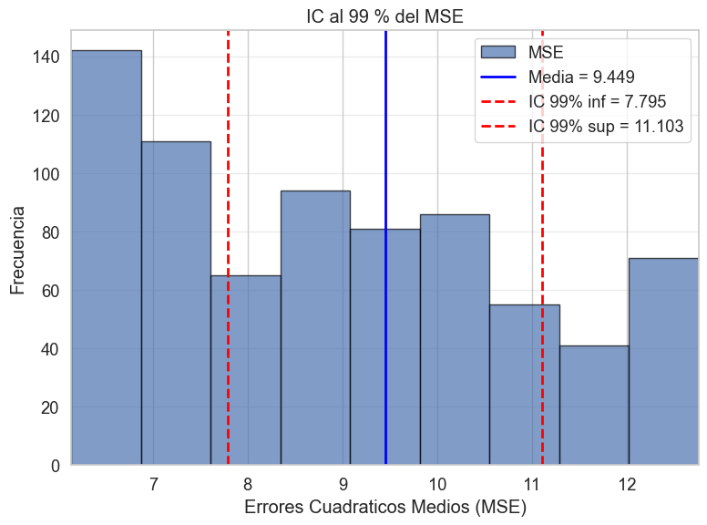

```python
# —————— Datos y cálculo del IC para MSE ——————
res_squared = res**2           # residuos al cuadrado
x = res_squared.copy()

confidence = 0.99
alfa = 1 - confidence

m = x.mean()
s = x.std(ddof=0)
n = len(x)
Z_crit = abs(norm.ppf(1 - alfa/2))

lower = m - Z_crit * s / np.sqrt(n)
upper = m + Z_crit * s / np.sqrt(n)

# —————— Definir margen y zoom alrededor del IC ——————
delta = upper - lower
margen = delta * 0.5           # 50% extra de cada lado
xmin_zoom = max(0, lower - margen)
xmax_zoom = upper + margen

# —————— Gráfico ——————
fig, ax = plt.subplots(figsize=(8, 6))

# Histograma zoomed
bins_zoom = np.linspace(xmin_zoom, xmax_zoom, 10)
ax.hist(x, bins=bins_zoom, alpha=0.7, edgecolor='black', label='MSE')

# Líneas de media y del intervalo de confianza
ax.axvline(m,     color='blue', linestyle='-',  linewidth=2, label=f'Media = {m:.3f}')
ax.axvline(lower, color='red',  linestyle='--', linewidth=2, label=f'IC 99% inf = {lower:.3f}')
ax.axvline(upper, color='red',  linestyle='--', linewidth=2, label=f'IC 99% sup = {upper:.3f}')

# Aplicar zoom en el eje X
ax.set_xlim(xmin_zoom, xmax_zoom)

# Etiquetas y estilo
ax.set_title('IC al 99 % del MSE')
ax.set_xlabel('Errores Cuadraticos Medios (MSE)')
ax.set_ylabel('Frecuencia')
ax.legend(loc='upper right')
ax.grid(axis='y', alpha=0.4)

plt.tight_layout()
plt.show()
```

Con un 99 % de confianza, el MSE verdadero de nuestro modelo se sitúa entre 7,795 y 11,103; aunque este intervalo (≈3,308) es más amplio que el del MAE, sigue reflejando una variabilidad moderada y confirma la solidez y consistencia del desempeño en términos de error cuadrático medio.

#### **5.4.3 Intervalo de confianza para el MAPE los residuos**

De Nuevo, por el TLC se tiene que un intervalo de confianza al 99% para el MAPE es:

```python
res_abs_percentage = np.abs((pred_test - y_test) / y_test)

confidence = 0.99
alfa = 1 - confidence

m = res_abs_percentage.mean()  # Media del MAPE
s = res_abs_percentage.std()   # Desviación estándar del MAPE
Z_crit = np.abs(norm.ppf(1 - (alfa / 2)))

out = (m - (s * Z_crit / np.sqrt(len(res_abs_percentage))), m + (s * Z_crit / np.sqrt(len(res_abs_percentage))))
out
```

```
(np.float64(0.0025893991822360687), np.float64(0.00326681123988217))
```

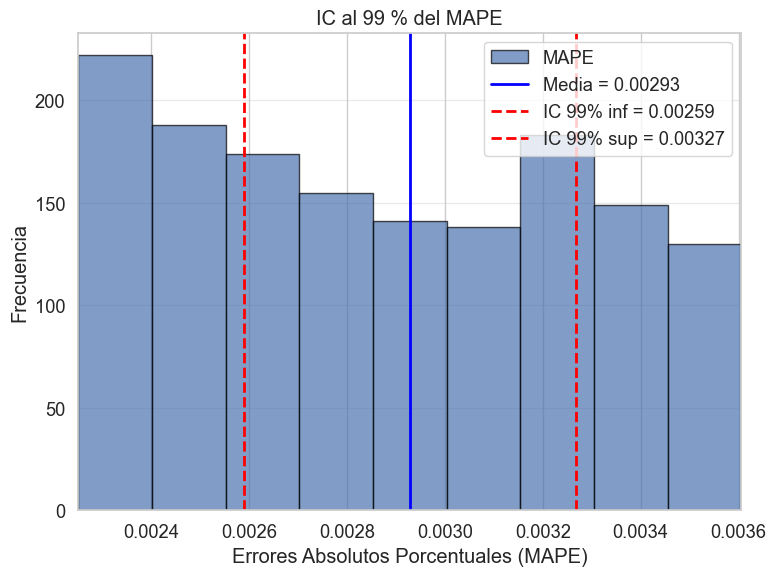

```python
# —————— Datos y cálculo del IC para MAPE ——————
res_abs_percentage = np.abs((pred_test - y_test) / y_test)

confidence = 0.99
alfa = 1 - confidence

m = res_abs_percentage.mean()        # Media del MAPE
s = res_abs_percentage.std(ddof=0)   # Desviación estándar (poblacional)
n = len(res_abs_percentage)
Z_crit = abs(norm.ppf(1 - alfa/2))

lower = m - Z_crit * s / np.sqrt(n)
upper = m + Z_crit * s / np.sqrt(n)

delta = upper - lower
margen = delta * 0.5
xmin_zoom = max(0, lower - margen)
xmax_zoom = upper + margen

# —————— Gráfico ——————
fig, ax = plt.subplots(figsize=(8, 6))

# Histograma zoomed
bins_zoom = np.linspace(xmin_zoom, xmax_zoom, 10)
ax.hist(res_abs_percentage, bins=bins_zoom, alpha=0.7, edgecolor='black', label='MAPE')

# Líneas de media y del intervalo de confianza
ax.axvline(m,     color='blue', linestyle='-',  linewidth=2, label=f'Media = {m:.5f}')
ax.axvline(lower, color='red',  linestyle='--', linewidth=2, label=f'IC 99% inf = {lower:.5f}')
ax.axvline(upper, color='red',  linestyle='--', linewidth=2, label=f'IC 99% sup = {upper:.5f}')

# Aplicar zoom en el eje X
ax.set_xlim(xmin_zoom, xmax_zoom)

# Etiquetas y estilo
ax.set_title('IC al 99 % del MAPE')
ax.set_xlabel('Errores Absolutos Porcentuales (MAPE)')
ax.set_ylabel('Frecuencia')
ax.legend(loc='upper right')
ax.grid(axis='y', alpha=0.4)

plt.tight_layout()
plt.show()
```

Con un 99 % de confianza, el MAPE verdadero de nuestro modelo se sitúa entre 0,00259 y 0,00327; este intervalo estrecho alrededor de la media (0,00293) indica muy poca variabilidad porcentual y respalda la consistencia y precisión de las predicciones relativas.

### **5.5 Comparación de la media simple de los conjuntos de entrenamiento y validación**

```python
pred_val = rf1.predict(x_val)
print("Metricas del modelo en validación: ")
print("MSE: " +  str(mean_squared_error(y_val, pred_val)))
print("MAE: " + str(mean_absolute_error(y_val, pred_val)))
print("MAPE: "+ str(mean_absolute_percentage_error(y_val, pred_val)))
```

```
Metricas del modelo en validación:
MSE: 9.69856848540296
MAE: 0.13088736928232206
MAPE: 0.003377570657279556
```

```python
pred_test = modelo_final.predict(x_test)
print("Metricas modelo elegido en prueba: ")
print("MSE: " +  str(mean_squared_error(y_test, pred_test)))
print("MAE: " + str(mean_absolute_error(y_test, pred_test)))
print("MAPE: "+ str(mean_absolute_percentage_error(y_test, pred_test)))
```

```
Metricas modelo elegido en prueba:
MSE: 9.448727286614789
MAE: 0.11551789055137983
MAPE: 0.0029281052110591145
```

```python
pred_val.mean()
```

```
np.float64(109.526853977658)
```

```python
pred_test.mean()
```

```
np.float64(109.40804387898417)
```

#### **5.5.1 Wilcoxon signed rank test**

Utilizaremos este test no paramétrico , el cual es la alternativa no parámetrica al paired sample t-test, pues este hace mucho menos supuestos sobre los datos que la versión paramétrica. Además, se utiliza el Wilcoxon signed rank test y no el Wilcoxon rank-sum test, pues el primero se usa para muestras emparejadas como este caso y el segundo con muestras independientes.

Nuestras muestras claramente están emparejadas, pues compararemos las predicciones del modelo final con el modelo basado en la media simple (la predicción constante) usando las mismas muestras de prueba. Esto implica que las muestras son emparejadas, porque las predicciones del modelo final y el modelo de media simple corresponden a los mismos datos de prueba.

```python
# Media simple con el conjunto de entrenamiento y validación
modelo_media = y_train_val.mean()

# Predicciones del modelo final y del modelo de la media con los conjuntos de prueba
pred_modelo_final = modelo_final.predict(x_test)
pred_modelo_media = np.full_like(y_test, modelo_media)
```

```python
pred_modelo_media.size
```

```
764818
```

```python
pred_modelo_final.size
```

```
764818
```

```python
# Residuos correspondientes a los errores absolutos de cada modelo para poder hacer la comparación
err_abs_modelo_final = abs(y_test - pred_modelo_final)
err_abs_modelo_media = abs(y_test - pred_modelo_media)
```

Veamos por ejemplo la media de los errores absolutos de cada conjunto de errores:

```python
err_abs_modelo_media.mean()
```

```
np.float64(75.5247790501236)
```

```python
err_abs_modelo_final.mean()  # El mismo MAE que ya teníamos
```

```
np.float64(0.11551789055138045)
```

En términos de MAE se nota que nuestro modelo final es mucho más eficiente que el modelo que siempre calcula la media simple. Sin embargo, veámoslo ahora con el test de Wilicoxon:

```python
from scipy import stats

stats.wilcoxon(x=err_abs_modelo_final, y=err_abs_modelo_media, alternative='less')  #alternative less para probar que x es menor que y
```

```
WilcoxonResult(statistic=np.float64(88179618.0), pvalue=np.float64(0.0))
```

Por lo tanto, como el Valor p es cero, con un nivel de confianza del 100% podemos concluir que los errores absolutos del modelo final son inferiores a los del modelo alternativo que calcula la media simple, es decir, el modelo final es más eficiente.

#### **5.5.2 Guardar el modelo escogido**

```python
# Antes de guardar se entrena con la totalidad de los datos
modelo_guardar = modelo_final.fit(data_x, data_y)
```

Verifiquemos las metricas del modelo ya entrenado con todo el conjunto de datos.

```python
pred_val1 = modelo_guardar.predict(x_val)
print("Metricas del modelo final: ")
print("MSE: " +  str(mean_squared_error(y_val, pred_val1)))
print("MAE: " + str(mean_absolute_error(y_val, pred_val1)))
print("MAPE: "+ str(mean_absolute_percentage_error(y_val, pred_val1)))
```

```
Metricas del modelo final:
MSE: 1.588444956034884
MAE: 0.04385260714134772
MAPE: 0.0011652976263749682
```

```python
# Guardar el modelo en un pickle
import pickle as pk
pk.dump(modelo_guardar, open("modelo_final.pickle", 'wb'))
```